# From VGG to ResNet

Implement and compare VGG-16 and ResNet-18 for image classification. Explore advanced techniques to improve model performance and the transition from standard deep CNNs to networks with residual connections. The expected accuracy is above 75% for the base model and 80% for the improved model.

## Step 1: Data preparation

1. Load CNN dataset.

```python
import os
from torchvision import datasets, transforms
from torch.utils.data import DataLoader


# Set seeds for reproducibility
import torch, random
random.seed(1227)
torch.manual_seed(1227)
torch.cuda.manual_seed_all(1227)
torch.backends.cudnn.deterministic = True
torch.backends.cudnn.benchmark = False
import numpy as np
np.random.seed(1227)

# Path to the unzipped dataset folder
data_dir = '/content/cnn_part_2_dataset'

# Define the transformer to convert to tensor
transform = transforms.Compose([
    transforms.Resize((64, 64)),  # Ensures input is correct size
    transforms.ToTensor(),        # Converts to [0, 1] float tensor
])

# Load the dataset using ImageFolder
dataset = datasets.ImageFolder(root=data_dir, transform=transform)
```

Analyze the dataset.

```python
import numpy as np

# Number of samples
num_samples = len(dataset)

# Number of classes
num_classes = len(dataset.classes)

# Class names
class_names = dataset.classes

# Shape of a sample image
sample_img, sample_label = dataset[0]
img_shape = sample_img.shape

# Stack all image tensors
all_imgs = torch.stack([img for img, _ in dataset])

# Compute pixel stats
mean = all_imgs.mean().item()
std = all_imgs.std().item()
min_pixel = all_imgs.min().item()
max_pixel = all_imgs.max().item()

# Print results
print(f"Total samples: {num_samples}")
print(f"Number of classes: {num_classes}")
print(f"Image shape (C, H, W): {img_shape}")
print(f"Classes: {class_names}")
print(f"Mean pixel value: {mean:.4f}")
print(f"Standard deviation: {std:.4f}")
print(f"Min pixel value: {min_pixel}")
print(f"Max pixel value: {max_pixel}")
```

```
Total samples: 30000
Number of classes: 3
Image shape (C, H, W): torch.Size([3, 64, 64])
Classes: ['dogs', 'food', 'vehicles']
Mean pixel value: 0.4463
Standard deviation: 0.2766
Min pixel value: 0.0
Max pixel value: 1.0
```

- The dataset consists of 30,000 RGB images of shape (3, 64, 64), distributed across three classes: `dogs`, `food`, and `vehicles`.
- The mean pixel value across the dataset is **0.4463** with a standard deviation of **0.2766**, indicating moderate brightness and contrast.
- Pixel values are correctly normalized within the range [0.0, 1.0], as confirmed by the minimum and maximum values of **0.0** and **1.0**, respectively.
2. Create at least three different visualizations to explore the dataset. Provide a short description explaining what each visualization shows.
- **Display a grid of sample images from each class (e.g., a 3x3 grid showing 3 dogs, 3 cars, and 3 food items**

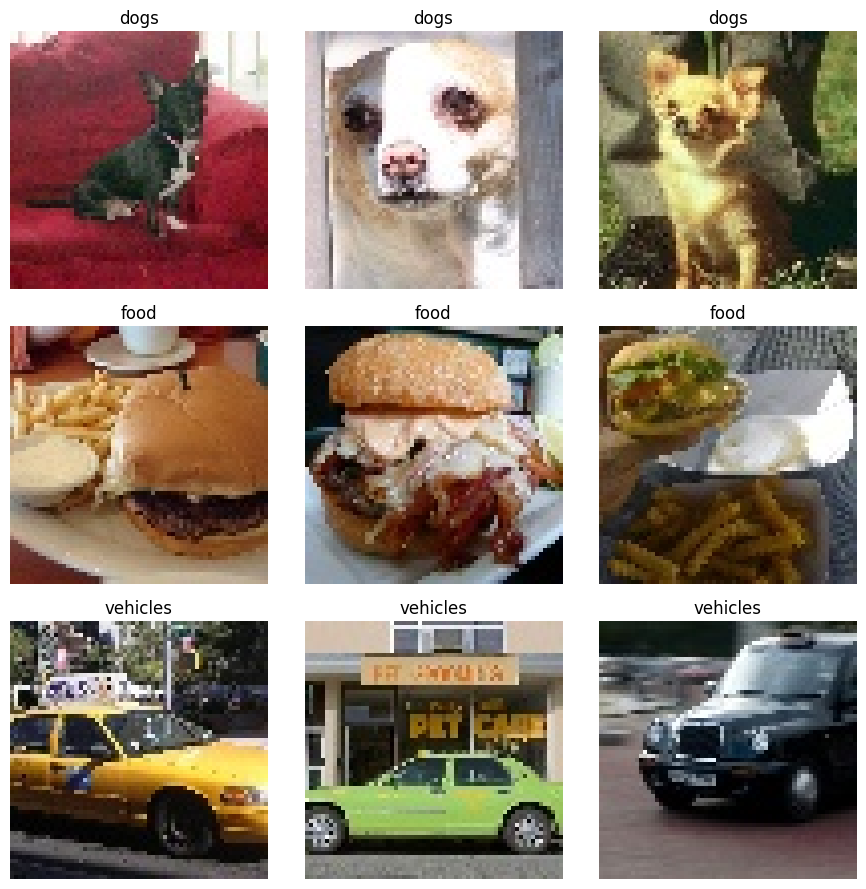

```python
import matplotlib.pyplot as plt

fig, axes = plt.subplots(3, 3, figsize=(9, 9))
class_names = dataset.classes
class_counts = {i: 0 for i in range(len(class_names))}

for img, label in dataset:
    if class_counts[label] < 3:
        ax = axes[label][class_counts[label]]
        ax.imshow(img.permute(1, 2, 0))
        ax.set_title(f"{class_names[label]}")
        ax.axis('off')
        class_counts[label] += 1
    if all(v == 3 for v in class_counts.values()):
        break

plt.tight_layout()
plt.show()
```

**Description:** A 3×3 grid displays three representative images from each class. There are three types of cars in three colours, set against three different backgrounds. Even the food features three different burgers, and there are three distinct breeds of dogs, which highlights the intra-class variation that CNN must learn to generalize.

- **Bar chart showing the number of images per class**

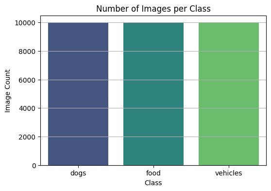

```python
import seaborn as sns
import pandas as pd

# Count images per class
class_indices = [label for _, label in dataset]
class_counts_df = pd.DataFrame(class_indices, columns=['label'])
class_counts_df['class'] = class_counts_df['label'].map(lambda x: class_names[x])

# Plot
plt.figure(figsize=(6, 4))
sns.countplot(data=class_counts_df, x='class', hue='class', palette='viridis', legend=False)
plt.title("Number of Images per Class")
plt.ylabel("Image Count")
plt.xlabel("Class")
plt.grid(axis='y')
plt.show()
```

**Description:** The dataset is perfectly balanced, with 10,000 images in each of the three classes, which ensures that class imbalance will not bias the model during training. Therefore, we do not need to worry about artificially balancing classes.

- **Histogram of pixel values for a single channel of a few sample images. This helps understand the data's distribution and choose appropriate normalization**

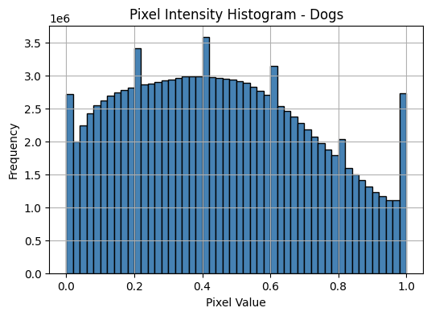

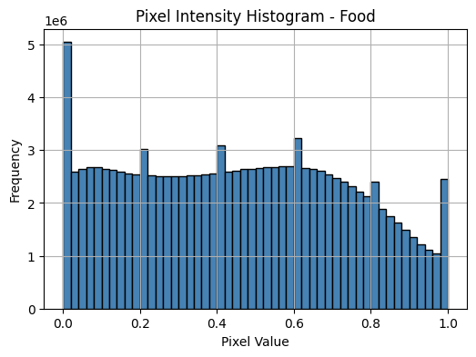

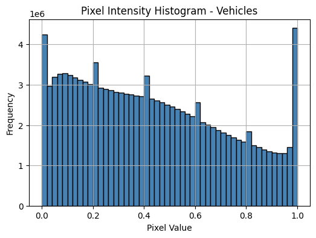

```python
import torch

# Group images by class
class_pixel_values = {label: [] for label in range(len(class_names))}

# Separate and flatten pixel values by class
for img, label in dataset:
    class_pixel_values[label].append(img.view(-1))

# Stack and convert to NumPy
for label in range(len(class_names)):
    pixels = torch.cat(class_pixel_values[label]).numpy()
    plt.figure(figsize=(6, 4))
    plt.hist(pixels, bins=50, color='steelblue', edgecolor='black')
    plt.title(f"Pixel Intensity Histogram - {class_names[label].capitalize()}")
    plt.xlabel("Pixel Value")
    plt.ylabel("Frequency")
    plt.grid(True)
    plt.show()
```

- The pixel intensity distribution for dog images is moderately spread, peaking around 0.2–0.6. This might suggests a mix of mid-tone backgrounds and dog fur, with few extreme light or dark regions.
- Food images show a more diverse distribution, with noticeable spikes at both low and high intensities. This indicates more contrast and brightness variation, maybe due to lighting and plating styles in food photography.
- Vehicle images have a skewed pixel intensity distribution, with strong frequencies near 0 and 1. This might suggests more presence of bright highlights (e.g., reflections) and dark shadows, consistent with outdoor and metallic surfaces.
3. Preprocess the dataset.

**Normalize pixel values using dataset-specific mean and standard deviation**

```python
transform = transforms.Compose([
    transforms.Resize((64, 64)),
    transforms.ToTensor(),
    transforms.Normalize(mean, std)
])

# Reload the dataset with the updated transform
dataset = datasets.ImageFolder(root=data_dir, transform=transform)
```

**Convert target labels to numerical class indices (torch.LongTensor)**

- This is automatically handled by ImageFolder, which maps each class folder name to a unique integer label.

**Address class imbalance**

- Not needed in this case, as all 3 classes have exactly 10,000 samples. Verified earlier using the class distribution bar chart.
4. Split the dataset into training, testing, and validation sets.

```python
from sklearn.model_selection import train_test_split
from torch.utils.data import Subset, DataLoader
import numpy as np

# Get all dataset indices
indices = list(range(len(dataset)))
labels = [label for _, label in dataset]  # Needed for stratified sampling

# First split: Train vs (Val + Test)
train_indices, val_test_indices = train_test_split(
    indices,
    test_size=0.3,
    stratify=labels,
    random_state=1227
)

# Second split: Val vs Test (50% of 30% → 15%)
val_test_labels = [labels[i] for i in val_test_indices]
val_indices, test_indices = train_test_split(
    val_test_indices,
    test_size=0.5,
    stratify=val_test_labels,
    random_state=1227
)

# Create subset datasets
train_dataset = Subset(dataset, train_indices)
val_dataset = Subset(dataset, val_indices)
test_dataset = Subset(dataset, test_indices)

# Print split sizes
print(f"Training set size: {len(train_dataset)}")
print(f"Validation set size: {len(val_dataset)}")
print(f"Test set size: {len(test_dataset)}")
```

```
Training set size: 21000
Validation set size: 4500
Test set size: 4500
```

**Class Distribution**

```python
from collections import Counter

def get_label_counts(subset):
    labels = [dataset[i][1] for i in subset.indices]
    return Counter(labels)

print("Train class counts:", get_label_counts(train_dataset))
print("Val class counts:", get_label_counts(val_dataset))
print("Test class counts:", get_label_counts(test_dataset))
```

```
Train class counts: Counter({1: 7000, 2: 7000, 0: 7000})
Val class counts: Counter({0: 1500, 2: 1500, 1: 1500})
Test class counts: Counter({1: 1500, 0: 1500, 2: 1500})
```

## Step 2: Implementing VGG

1. Implement the VGG-16 (Version C) architecture.

```python
import torch.nn as nn
import torch.nn.functional as F

class VGG16Custom(nn.Module):
    def __init__(self, num_classes=3):
        super(VGG16Custom, self).__init__()

        self.features = nn.Sequential(
            # Block 1
            nn.Conv2d(3, 64, kernel_size=3, padding=1), nn.ReLU(inplace=True),
            nn.Conv2d(64, 64, kernel_size=3, padding=1), nn.ReLU(inplace=True),
            nn.MaxPool2d(kernel_size=2, stride=2),  # 64x64 → 32x32

            # Block 2
            nn.Conv2d(64, 128, kernel_size=3, padding=1), nn.ReLU(inplace=True),
            nn.Conv2d(128, 128, kernel_size=3, padding=1), nn.ReLU(inplace=True),
            nn.MaxPool2d(kernel_size=2, stride=2),  # 32x32 → 16x16

            # Block 3
            nn.Conv2d(128, 256, kernel_size=3, padding=1), nn.ReLU(inplace=True),
            nn.Conv2d(256, 256, kernel_size=3, padding=1), nn.ReLU(inplace=True),
            nn.Conv2d(256, 256, kernel_size=3, padding=1), nn.ReLU(inplace=True),
            nn.MaxPool2d(kernel_size=2, stride=2),  # 16x16 → 8x8

            # Block 4 (no pooling)
            nn.Conv2d(256, 512, kernel_size=3, padding=1), nn.ReLU(inplace=True),
            nn.Conv2d(512, 512, kernel_size=3, padding=1), nn.ReLU(inplace=True),
            nn.Conv2d(512, 512, kernel_size=3, padding=1), nn.ReLU(inplace=True),

            # Block 5 (no pooling)
            nn.Conv2d(512, 512, kernel_size=3, padding=1), nn.ReLU(inplace=True),
            nn.Conv2d(512, 512, kernel_size=3, padding=1), nn.ReLU(inplace=True),
            nn.Conv2d(512, 512, kernel_size=3, padding=1), nn.ReLU(inplace=True),
        )

        # After 3 pools → 8x8 spatial, 512 channels
        self.classifier = nn.Sequential(
            nn.Flatten(),  # 512 * 8 * 8
            nn.Linear(512 * 8 * 8, 4096), nn.ReLU(True),
            nn.Dropout(p=0.5),
            nn.Linear(4096, 4096), nn.ReLU(True),
            nn.Dropout(p=0.5),
            nn.Linear(4096, num_classes)  # Output layer for 3 classes
        )

    def forward(self, x):
        x = self.features(x)
        x = self.classifier(x)
        return x
```

Note: Intentionally did not apply a softmax activation in the final layer. `CrossEntropy` will be used as the criterion. Therefore, `torch.nn.CrossEntropyLoss` automatically applies LogSoftmax followed by NLLLoss internally. Adding an explicit softmax would be redundant and may interfere with gradient calculations during training.

https://pytorch.org/docs/stable/generated/torch.nn.CrossEntropyLoss.html

2. Use dropout and learning rate scheduler. Experiment with weight initialization strategies.
- **Dropout:** Already Applied in `classifier`
- **Learning Rate Scheduler**

```python
# Learning rate scheduler setup using later with two different optimizers


# scheduler = torch.optim.lr_scheduler.StepLR(optimizer, step_size=10, gamma=0.1)
```

- **Experiment with weight initialization strategies**

```python
def init_weights_he(m):
    if isinstance(m, nn.Conv2d) or isinstance(m, nn.Linear):
        nn.init.kaiming_normal_(m.weight)

def init_weights_xavier(m):
    if isinstance(m, nn.Conv2d) or isinstance(m, nn.Linear):
        nn.init.xavier_uniform_(m.weight)

# Will call above functions before training
```

3. Train your VGG-16 model.

```python
import time
import copy
import pickle
from torch import nn

def train_model(model, train_loader, val_loader, criterion, optimizer,
                scheduler, num_epochs, device, model_name):

    # Track total training time
    since = time.time()

    # Store initial model weights (for restoring best model later)
    best_model_wts = copy.deepcopy(model.state_dict())
    best_acc = 0.0 # best validation accuracy seen so far

    # Initialize lists to track losses and accuracies per epoch
    train_loss_history = []
    val_loss_history = []
    train_acc_history = []
    val_acc_history = []

    for epoch in range(num_epochs):
        epoch_start = time.time()  # per-epoch start

        # === Training Phase ===
        model.train() # set model to training mode
        train_loss = 0.0
        train_correct = 0
        train_total = 0

        for inputs, labels in train_loader:
            inputs, labels = inputs.to(device), labels.to(device)

            optimizer.zero_grad() # reset gradients
            outputs = model(inputs)
            _, preds = torch.max(outputs, 1)
            loss = criterion(outputs, labels)
            loss.backward()
            optimizer.step()

            train_loss += loss.item() * inputs.size(0)
            train_correct += (preds == labels).sum().item()
            train_total += labels.size(0)

        train_loss /= train_total
        train_acc = train_correct / train_total
        train_loss_history.append(train_loss)
        train_acc_history.append(train_acc)

        # === Validation Phase ===
        model.eval() # set model to evaluation mode
        val_loss = 0.0
        val_correct = 0
        val_total = 0

        with torch.no_grad():
            for inputs, labels in val_loader:
                inputs, labels = inputs.to(device), labels.to(device)
                outputs = model(inputs)
                _, preds = torch.max(outputs, 1)
                loss = criterion(outputs, labels)
                val_loss += loss.item() * inputs.size(0)
                val_correct += (preds == labels).sum().item()
                val_total += labels.size(0)

        val_loss /= val_total
        val_acc = val_correct / val_total
        val_loss_history.append(val_loss)
        val_acc_history.append(val_acc)

        # Save the best model based on validation accuracy
        if val_acc > best_acc:
            best_acc = val_acc
            best_model_wts = copy.deepcopy(model.state_dict())

        # Step learning rate scheduler if provided
        if scheduler:
            scheduler.step()

        # Print epoch summary
        epoch_end = time.time()
        print(f"Epoch {epoch+1:2d}/{num_epochs} | "
              f"Train Loss: {train_loss:.4f} Train Acc: {train_acc:.4f} | "
              f"Val Loss: {val_loss:.4f} Train Acc: {val_acc:.4f} | "
              f"Time: {(epoch_end - epoch_start):.2f}s")

    # Final training summary
    total_time = time.time() - since
    print(f"\nTraining complete in {total_time / 60:.2f} minutes")
    print(f"Best Val Accuracy: {best_acc:.4f}")

    # Save model weights and history if name provided
    if model_name:
        torch.save(best_model_wts, f"{model_name}_best_model.pt")
        print(f"Saved best model: {model_name}_best_model.pt")

        history = {
            'train_loss': train_loss_history,
            'val_loss': val_loss_history,
            'train_acc': train_acc_history,
            'val_acc': val_acc_history,
            'best_val_acc': best_acc
        }
        with open(f"{model_name}_history.pkl", 'wb') as f:
            pickle.dump(history, f)
        print(f"Saved training log: {model_name}_history.pkl")

    # Load best weights before returning
    model.load_state_dict(best_model_wts)
    return model, history
```

# **Experiment 1**: He Initialization + Adam Optimizer + Batch Size 64

```python
# Config
init = 'he'
optimizer_name = 'adam'
batch_size = 64
model_name = f"vgg16_{init}_{optimizer_name}_{batch_size}"

# DataLoader
train_loader = DataLoader(train_dataset, batch_size=batch_size, shuffle=True)
val_loader = DataLoader(val_dataset, batch_size=batch_size)

# Model
model = VGG16Custom(num_classes=3).to(device)
model.apply(init_weights_he)  # HE init

# Optimizer, Scheduler, Loss Function
optimizer = torch.optim.Adam(model.parameters(), lr=0.001)
scheduler = torch.optim.lr_scheduler.StepLR(optimizer, step_size=10, gamma=0.1)
criterion = nn.CrossEntropyLoss()

# Train
model, history = train_model(
    model=model,
    train_loader=train_loader,
    val_loader=val_loader,
    criterion=criterion,
    optimizer=optimizer,
    scheduler=scheduler,
    num_epochs=20,
    device=device,
    model_name=model_name
)
```

```
Epoch  1/20 | Train Loss: 15.1008 Train Acc: 0.3470 | Val Loss: 1.0991 Train Acc: 0.3333 | Time: 25.16s
Epoch  2/20 | Train Loss: 1.0990 Train Acc: 0.3333 | Val Loss: 1.0989 Train Acc: 0.3333 | Time: 23.58s
Epoch  3/20 | Train Loss: 1.0990 Train Acc: 0.3319 | Val Loss: 1.0988 Train Acc: 0.3333 | Time: 23.52s
Epoch  4/20 | Train Loss: 1.0989 Train Acc: 0.3318 | Val Loss: 1.0987 Train Acc: 0.3333 | Time: 23.57s
Epoch  5/20 | Train Loss: 1.0989 Train Acc: 0.3318 | Val Loss: 1.0988 Train Acc: 0.3333 | Time: 23.57s
Epoch  6/20 | Train Loss: 1.0990 Train Acc: 0.3319 | Val Loss: 1.0986 Train Acc: 0.3333 | Time: 23.59s
Epoch  7/20 | Train Loss: 1.0991 Train Acc: 0.3306 | Val Loss: 1.0988 Train Acc: 0.3333 | Time: 23.73s
Epoch  8/20 | Train Loss: 1.0988 Train Acc: 0.3340 | Val Loss: 1.0986 Train Acc: 0.3333 | Time: 23.81s
Epoch  9/20 | Train Loss: 1.0987 Train Acc: 0.3363 | Val Loss: 1.0988 Train Acc: 0.3333 | Time: 23.63s

Training complete in 7.90 minutes
Best Val Accuracy: 0.3333
Saved best model: vgg16_he_adam_64_best_model.pt
Saved training log: vgg16_he_adam_64_history.pkl
```

# **Experiment 2**: Xavier Initialization + SGD Optimizer + Batch Size 128

```python
# Config
init = 'xavier'
optimizer_name = 'sgd'
batch_size = 128
model_name = f"vgg16_{init}_{optimizer_name}_{batch_size}"

# DataLoader
train_loader = DataLoader(train_dataset, batch_size=batch_size, shuffle=True)
val_loader = DataLoader(val_dataset, batch_size=batch_size)

# Model
model = VGG16Custom(num_classes=3).to(device)
model.apply(init_weights_xavier)  # Xavier init

# Optimizer, Scheduler, Loss
optimizer = torch.optim.SGD(model.parameters(), lr=0.01, momentum=0.9)
scheduler = torch.optim.lr_scheduler.StepLR(optimizer, step_size=10, gamma=0.1)
criterion = nn.CrossEntropyLoss()

# Train
model, history = train_model(
    model=model,
    train_loader=train_loader,
    val_loader=val_loader,
    criterion=criterion,
    optimizer=optimizer,
    scheduler=scheduler,
    num_epochs=20,
    device=device,
    model_name=model_name
)
```

```
Epoch  1/20 | Train Loss: 0.9401 Train Acc: 0.5079 | Val Loss: 0.6970 Train Acc: 0.7129 | Time: 20.62s
Epoch  2/20 | Train Loss: 0.5597 Train Acc: 0.7729 | Val Loss: 0.5656 Train Acc: 0.7851 | Time: 20.72s
Epoch  3/20 | Train Loss: 0.4706 Train Acc: 0.8152 | Val Loss: 0.5728 Train Acc: 0.7633 | Time: 20.65s
Epoch  4/20 | Train Loss: 0.4211 Train Acc: 0.8374 | Val Loss: 0.4058 Train Acc: 0.8444 | Time: 20.63s
Epoch  5/20 | Train Loss: 0.3842 Train Acc: 0.8513 | Val Loss: 0.3773 Train Acc: 0.8660 | Time: 20.64s
Epoch  6/20 | Train Loss: 0.3551 Train Acc: 0.8652 | Val Loss: 0.3632 Train Acc: 0.8633 | Time: 20.76s
Epoch  7/20 | Train Loss: 0.3136 Train Acc: 0.8821 | Val Loss: 0.2940 Train Acc: 0.8931 | Time: 20.61s
Epoch  8/20 | Train Loss: 0.2883 Train Acc: 0.8920 | Val Loss: 0.3100 Train Acc: 0.8836 | Time: 20.69s
Epoch  9/20 | Train Loss: 0.2758 Train Acc: 0.8988 | Val Loss: 0.2780 Train Acc: 0.9018 | Time: 20.62s

Training complete in 6.87 minutes
Best Val Accuracy: 0.9289
Saved best model: vgg16_xavier_sgd_128_best_model.pt
Saved training log: vgg16_xavier_sgd_128_history.pkl
```

# **Experiment 3:** He Initialization + SGD Optimizer + Batch Size 128

```python
# Config
init = 'he'
optimizer_name = 'sgd'
batch_size = 128
model_name = f"vgg16_{init}_{optimizer_name}_{batch_size}"

# DataLoader
train_loader = DataLoader(train_dataset, batch_size=batch_size, shuffle=True)
val_loader = DataLoader(val_dataset, batch_size=batch_size)

# Model
model = VGG16Custom(num_classes=3).to(device)
model.apply(init_weights_he)

# Optimizer, Scheduler, Loss
optimizer = torch.optim.SGD(model.parameters(), lr=0.01, momentum=0.9)
scheduler = torch.optim.lr_scheduler.StepLR(optimizer, step_size=10, gamma=0.1)
criterion = nn.CrossEntropyLoss()

# Train
model, history = train_model(
    model=model,
    train_loader=train_loader,
    val_loader=val_loader,
    criterion=criterion,
    optimizer=optimizer,
    scheduler=scheduler,
    num_epochs=20,
    device=device,
    model_name=model_name
)
```

```
Epoch  1/20 | Train Loss: 0.9868 Train Acc: 0.5255 | Val Loss: 0.6287 Train Acc: 0.7496 | Time: 20.59s
Epoch  2/20 | Train Loss: 0.5593 Train Acc: 0.7684 | Val Loss: 0.5247 Train Acc: 0.7840 | Time: 20.64s
Epoch  3/20 | Train Loss: 0.4291 Train Acc: 0.8318 | Val Loss: 0.6764 Train Acc: 0.7091 | Time: 20.62s
Epoch  4/20 | Train Loss: 0.3891 Train Acc: 0.8507 | Val Loss: 0.3322 Train Acc: 0.8769 | Time: 20.56s
Epoch  5/20 | Train Loss: 0.3250 Train Acc: 0.8750 | Val Loss: 0.3166 Train Acc: 0.8838 | Time: 20.58s
Epoch  6/20 | Train Loss: 0.2873 Train Acc: 0.8918 | Val Loss: 0.2772 Train Acc: 0.8989 | Time: 20.56s
Epoch  7/20 | Train Loss: 0.2689 Train Acc: 0.8992 | Val Loss: 0.4569 Train Acc: 0.8309 | Time: 20.65s
Epoch  8/20 | Train Loss: 0.2687 Train Acc: 0.8979 | Val Loss: 0.2690 Train Acc: 0.8980 | Time: 20.65s
Epoch  9/20 | Train Loss: 0.2257 Train Acc: 0.9161 | Val Loss: 0.3522 Train Acc: 0.8613 | Time: 20.77s

Training complete in 6.86 minutes
Best Val Accuracy: 0.9347
Saved best model: vgg16_he_sgd_128_best_model.pt
Saved training log: vgg16_he_sgd_128_history.pkl
```

# **Experiment 4:** Xavier Initialization + Adam Optimizer + Batch Size 64

```python
# Config
init = 'xavier'
optimizer_name = 'adam'
batch_size = 64
model_name = f"vgg16_{init}_{optimizer_name}_{batch_size}"

#  DataLoader
train_loader = DataLoader(train_dataset, batch_size=batch_size, shuffle=True)
val_loader = DataLoader(val_dataset, batch_size=batch_size)

#  Model
model = VGG16Custom(num_classes=3).to(device)
model.apply(init_weights_xavier)

#  Optimizer, Scheduler, Loss
optimizer = torch.optim.Adam(model.parameters(), lr=0.001)
scheduler = torch.optim.lr_scheduler.StepLR(optimizer, step_size=10, gamma=0.1)
criterion = nn.CrossEntropyLoss()

# Train
model, history = train_model(
    model=model,
    train_loader=train_loader,
    val_loader=val_loader,
    criterion=criterion,
    optimizer=optimizer,
    scheduler=scheduler,
    num_epochs=20,
    device=device,
    model_name=model_name
)
```

```
Epoch  1/20 | Train Loss: 1.1703 Train Acc: 0.3301 | Val Loss: 1.0999 Train Acc: 0.3333 | Time: 23.41s
Epoch  2/20 | Train Loss: 1.0992 Train Acc: 0.3322 | Val Loss: 1.0987 Train Acc: 0.3333 | Time: 23.29s
Epoch  3/20 | Train Loss: 1.0993 Train Acc: 0.3290 | Val Loss: 1.0987 Train Acc: 0.3333 | Time: 23.29s
Epoch  4/20 | Train Loss: 1.0992 Train Acc: 0.3276 | Val Loss: 1.0986 Train Acc: 0.3333 | Time: 23.37s
Epoch  5/20 | Train Loss: 1.0989 Train Acc: 0.3315 | Val Loss: 1.0986 Train Acc: 0.3333 | Time: 23.33s
Epoch  6/20 | Train Loss: 1.0989 Train Acc: 0.3300 | Val Loss: 1.0987 Train Acc: 0.3333 | Time: 23.34s
Epoch  7/20 | Train Loss: 1.0990 Train Acc: 0.3303 | Val Loss: 1.0987 Train Acc: 0.3333 | Time: 23.40s
Epoch  8/20 | Train Loss: 1.0989 Train Acc: 0.3274 | Val Loss: 1.0987 Train Acc: 0.3333 | Time: 23.33s
Epoch  9/20 | Train Loss: 1.0987 Train Acc: 0.3302 | Val Loss: 1.0986 Train Acc: 0.3333 | Time: 23.41s

Training complete in 7.78 minutes
Best Val Accuracy: 0.3333
Saved best model: vgg16_xavier_adam_64_best_model.pt
Saved training log: vgg16_xavier_adam_64_history.pkl
```

# **Experiment 5:** He Initialization + AdamW Optimizer + Batch Size 128

```python
# Config
init = 'he'
optimizer_name = 'adamw'
batch_size = 128
model_name = f"vgg16_{init}_{optimizer_name}_{batch_size}"

# DataLoader
train_loader = DataLoader(train_dataset, batch_size=batch_size, shuffle=True)
val_loader = DataLoader(val_dataset, batch_size=batch_size)

# Model
model = VGG16Custom(num_classes=3).to(device)
model.apply(init_weights_he)

# Optimizer, Scheduler, Loss
optimizer = torch.optim.AdamW(model.parameters(), lr=0.001)
scheduler = torch.optim.lr_scheduler.StepLR(optimizer, step_size=10, gamma=0.1)
criterion = nn.CrossEntropyLoss()

# Train
model, history = train_model(
    model=model,
    train_loader=train_loader,
    val_loader=val_loader,
    criterion=criterion,
    optimizer=optimizer,
    scheduler=scheduler,
    num_epochs=20,
    device=device,
    model_name=model_name
)
```

```
Epoch  1/20 | Train Loss: 12.2471 Train Acc: 0.4990 | Val Loss: 0.6888 Train Acc: 0.6964 | Time: 21.34s
Epoch  2/20 | Train Loss: 0.6036 Train Acc: 0.7446 | Val Loss: 0.6209 Train Acc: 0.7556 | Time: 21.30s
Epoch  3/20 | Train Loss: 0.4626 Train Acc: 0.8166 | Val Loss: 0.4886 Train Acc: 0.8089 | Time: 21.26s
Epoch  4/20 | Train Loss: 0.3889 Train Acc: 0.8524 | Val Loss: 0.4140 Train Acc: 0.8333 | Time: 21.34s
Epoch  5/20 | Train Loss: 0.3365 Train Acc: 0.8710 | Val Loss: 0.3468 Train Acc: 0.8687 | Time: 21.44s
Epoch  6/20 | Train Loss: 0.3036 Train Acc: 0.8863 | Val Loss: 0.4259 Train Acc: 0.8358 | Time: 21.42s
Epoch  7/20 | Train Loss: 0.2926 Train Acc: 0.8924 | Val Loss: 0.3163 Train Acc: 0.8853 | Time: 21.53s
Epoch  8/20 | Train Loss: 0.2545 Train Acc: 0.9062 | Val Loss: 0.3551 Train Acc: 0.8731 | Time: 21.45s
Epoch  9/20 | Train Loss: 0.2366 Train Acc: 0.9138 | Val Loss: 0.3118 Train Acc: 0.8907 | Time: 21.40s

Training complete in 7.12 minutes
Best Val Accuracy: 0.9307
Saved best model: vgg16_he_adamw_128_best_model.pt
Saved training log: vgg16_he_adamw_128_history.pkl
```

# **Experiment 6:** Xavier Initialization + RMSprop Optimizer + Batch Size 64

```python
# Config
init = 'xavier'
optimizer_name = 'rmsprop'
batch_size = 64
model_name = f"vgg16_{init}_{optimizer_name}_{batch_size}"

# DataLoader
train_loader = DataLoader(train_dataset, batch_size=batch_size, shuffle=True)
val_loader = DataLoader(val_dataset, batch_size=batch_size)

#  Model
model = VGG16Custom(num_classes=3).to(device)
model.apply(init_weights_xavier)

#  Optimizer, Scheduler, Loss
optimizer = torch.optim.RMSprop(model.parameters(), lr=0.001, alpha=0.99)
scheduler = torch.optim.lr_scheduler.StepLR(optimizer, step_size=10, gamma=0.1)
criterion = nn.CrossEntropyLoss()

# Train
model, history = train_model(
    model=model,
    train_loader=train_loader,
    val_loader=val_loader,
    criterion=criterion,
    optimizer=optimizer,
    scheduler=scheduler,
    num_epochs=20,
    device=device,
    model_name=model_name
)
```

```
Epoch  1/20 | Train Loss: 291341419.1626 Train Acc: 0.5239 | Val Loss: 0.8357 Train Acc: 0.6016 | Time: 22.63s
Epoch  2/20 | Train Loss: 0.7405 Train Acc: 0.6611 | Val Loss: 0.8614 Train Acc: 0.5802 | Time: 22.52s
Epoch  3/20 | Train Loss: 0.7700 Train Acc: 0.6451 | Val Loss: 0.9759 Train Acc: 0.5940 | Time: 22.39s
Epoch  4/20 | Train Loss: 0.6846 Train Acc: 0.6962 | Val Loss: 0.6211 Train Acc: 0.7147 | Time: 22.43s
Epoch  5/20 | Train Loss: 0.8660 Train Acc: 0.6580 | Val Loss: 0.7215 Train Acc: 0.6424 | Time: 22.40s
Epoch  6/20 | Train Loss: 0.5567 Train Acc: 0.7716 | Val Loss: 0.5053 Train Acc: 0.8084 | Time: 22.36s
Epoch  7/20 | Train Loss: 0.5264 Train Acc: 0.7909 | Val Loss: 0.8075 Train Acc: 0.7133 | Time: 22.39s
Epoch  8/20 | Train Loss: 0.5027 Train Acc: 0.8068 | Val Loss: 0.5665 Train Acc: 0.7660 | Time: 22.47s
Epoch  9/20 | Train Loss: 1.0473 Train Acc: 0.7352 | Val Loss: 1.1172 Train Acc: 0.3387 | Time: 22.36s

Training complete in 7.49 minutes
Best Val Accuracy: 0.8951
Saved best model: vgg16_xavier_rmsprop_64_best_model.pt
Saved training log: vgg16_xavier_rmsprop_64_history.pkl
```

# **Experiment 7:** He Initialization + Adam Optimizer + Batch Size 32

```python
# Config
init = 'he'
optimizer_name = 'adam'
batch_size = 32
model_name = f"vgg16_{init}_{optimizer_name}_{batch_size}"

# DataLoader
train_loader = DataLoader(train_dataset, batch_size=batch_size, shuffle=True)
val_loader = DataLoader(val_dataset, batch_size=batch_size)

# Model
model = VGG16Custom(num_classes=3).to(device)
model.apply(init_weights_he)

# Optimizer, Scheduler, Loss
optimizer = torch.optim.Adam(model.parameters(), lr=0.001)
scheduler = torch.optim.lr_scheduler.StepLR(optimizer, step_size=10, gamma=0.1)
criterion = nn.CrossEntropyLoss()

# Train
model, history = train_model(
    model=model,
    train_loader=train_loader,
    val_loader=val_loader,
    criterion=criterion,
    optimizer=optimizer,
    scheduler=scheduler,
    num_epochs=20,
    device=device,
    model_name=model_name
)
```

```
Epoch  1/20 | Train Loss: 3.5729 Train Acc: 0.3536 | Val Loss: 1.0991 Train Acc: 0.3333 | Time: 27.34s
Epoch  2/20 | Train Loss: 1.0994 Train Acc: 0.3341 | Val Loss: 1.0997 Train Acc: 0.3333 | Time: 27.36s
Epoch  3/20 | Train Loss: 1.0991 Train Acc: 0.3319 | Val Loss: 1.0987 Train Acc: 0.3333 | Time: 27.24s
Epoch  4/20 | Train Loss: 1.0992 Train Acc: 0.3283 | Val Loss: 1.0987 Train Acc: 0.3333 | Time: 27.18s
Epoch  5/20 | Train Loss: 1.0988 Train Acc: 0.3363 | Val Loss: 1.0988 Train Acc: 0.3333 | Time: 27.18s
Epoch  6/20 | Train Loss: 1.0988 Train Acc: 0.3339 | Val Loss: 1.0988 Train Acc: 0.3333 | Time: 27.20s
Epoch  7/20 | Train Loss: 1.0990 Train Acc: 0.3327 | Val Loss: 1.0987 Train Acc: 0.3333 | Time: 27.31s
Epoch  8/20 | Train Loss: 1.0989 Train Acc: 0.3302 | Val Loss: 1.0986 Train Acc: 0.3333 | Time: 27.27s
Epoch  9/20 | Train Loss: 1.0988 Train Acc: 0.3308 | Val Loss: 1.0986 Train Acc: 0.3333 | Time: 27.21s

Training complete in 9.08 minutes
Best Val Accuracy: 0.3333
Saved best model: vgg16_he_adam_32_best_model.pt
Saved training log: vgg16_he_adam_32_history.pkl
```

# **Experiment 8:** Xavier Initialization + SGD + Batch Size 32

```python
#  Config
init = 'xavier'
optimizer_name = 'sgd'
batch_size = 32
model_name = f"vgg16_{init}_{optimizer_name}_{batch_size}_nodecay"

# DataLoader
train_loader = DataLoader(train_dataset, batch_size=batch_size, shuffle=True)
val_loader = DataLoader(val_dataset, batch_size=batch_size)

# Model
model = VGG16Custom(num_classes=3).to(device)
model.apply(init_weights_xavier)

# Optimizer, Scheduler, Loss
optimizer = torch.optim.SGD(model.parameters(), lr=0.01, momentum=0.9)
scheduler = torch.optim.lr_scheduler.StepLR(optimizer, step_size=10, gamma=0.1)
criterion = nn.CrossEntropyLoss()

# Train
model, history = train_model(
    model=model,
    train_loader=train_loader,
    val_loader=val_loader,
    criterion=criterion,
    optimizer=optimizer,
    scheduler=scheduler,
    num_epochs=20,
    device=device,
    model_name=model_name
)
```

```
Epoch  1/20 | Train Loss: 0.7178 Train Acc: 0.6656 | Val Loss: 0.5977 Train Acc: 0.7624 | Time: 23.59s
Epoch  2/20 | Train Loss: 0.4970 Train Acc: 0.8059 | Val Loss: 0.4278 Train Acc: 0.8342 | Time: 23.59s
Epoch  3/20 | Train Loss: 0.4240 Train Acc: 0.8383 | Val Loss: 0.5687 Train Acc: 0.7989 | Time: 23.79s
Epoch  4/20 | Train Loss: 0.3755 Train Acc: 0.8567 | Val Loss: 0.3658 Train Acc: 0.8638 | Time: 23.80s
Epoch  5/20 | Train Loss: 0.3261 Train Acc: 0.8793 | Val Loss: 0.3058 Train Acc: 0.8893 | Time: 23.53s
Epoch  6/20 | Train Loss: 0.2864 Train Acc: 0.8930 | Val Loss: 0.3368 Train Acc: 0.8836 | Time: 23.83s
Epoch  7/20 | Train Loss: 0.2637 Train Acc: 0.9047 | Val Loss: 0.3242 Train Acc: 0.8858 | Time: 23.83s
Epoch  8/20 | Train Loss: 0.2525 Train Acc: 0.9075 | Val Loss: 0.2520 Train Acc: 0.9067 | Time: 23.84s
Epoch  9/20 | Train Loss: 0.2350 Train Acc: 0.9143 | Val Loss: 0.2581 Train Acc: 0.9053 | Time: 23.58s

Training complete in 7.90 minutes
Best Val Accuracy: 0.9351
Saved best model: vgg16_xavier_sgd_32_nodecay_best_model.pt
Saved training log: vgg16_xavier_sgd_32_nodecay_history.pkl
```

**Experiment with at least two different optimizers (e.g., SGD, Adam, AdamW, RMSprop). Compare their performance and discuss your findings.**

# **Optimizer & Weight Initialization Comparison:**

# **'Xavier + Adam' vs 'Xavier + RMSprop'**

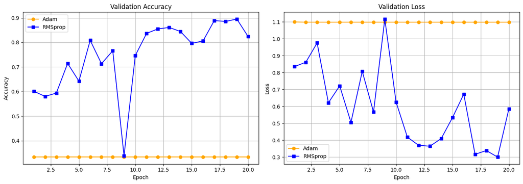

```python
import pickle
import matplotlib.pyplot as plt

# Load history logs
with open("vgg16_xavier_adam_64_history.pkl", "rb") as f:
    adam = pickle.load(f)

with open("vgg16_xavier_rmsprop_64_history.pkl", "rb") as f:
    rmsprop = pickle.load(f)

epochs = range(1, len(adam["val_acc"]) + 1)

# Plot side by side
plt.figure(figsize=(14, 5))

# --- 1. Validation Accuracy ---
plt.subplot(1, 2, 1)
plt.plot(epochs, adam["val_acc"], label="Adam", color='orange', marker='o')
plt.plot(epochs, rmsprop["val_acc"], label="RMSprop", color='blue', marker='s')
plt.title("Validation Accuracy")
plt.xlabel("Epoch")
plt.ylabel("Accuracy")
plt.grid(True)
plt.legend()

# --- 2. Validation Loss ---
plt.subplot(1, 2, 2)
plt.plot(epochs, adam["val_loss"], label="Adam", color='orange', marker='o')
plt.plot(epochs, rmsprop["val_loss"], label="RMSprop", color='blue', marker='s')
plt.title("Validation Loss")
plt.xlabel("Epoch")
plt.ylabel("Loss")
plt.grid(True)
plt.legend()

plt.tight_layout()
plt.show()
```

In contrast, the model trained with Adam completely failed to learn.It plateaued at 33.33% validation accuracy, equivalent to random guessing in a 3-class problem. This behavior persisted across all 20 epochs, indicating a potential issue with the optimizer’s sensitivity to learning rate in this configuration.

The comparison clearly shows that RMSprop significantly outperformed Adam in this setup.

# **'Xavier + Adam' VS 'He + Adam'**

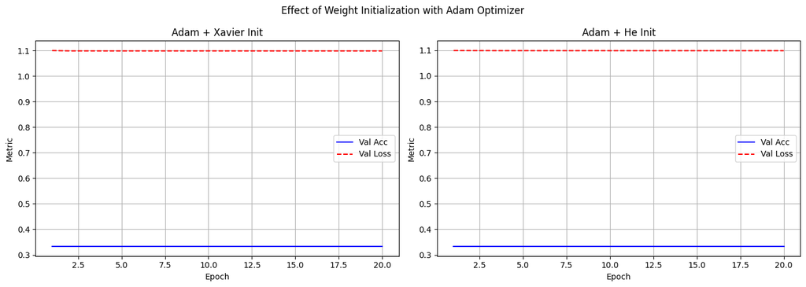

```python
import matplotlib.pyplot as plt
import pickle

# Load both histories
with open("vgg16_xavier_adam_64_history.pkl", "rb") as f:
    adam_xavier = pickle.load(f)

with open("vgg16_he_adam_64_history.pkl", "rb") as f:
    adam_he = pickle.load(f)

epochs = range(1, len(adam_xavier["val_acc"]) + 1)

fig, axes = plt.subplots(1, 2, figsize=(14, 5))

# --- Graph 1: Adam + Xavier ---
axes[0].plot(epochs, adam_xavier["val_acc"], label="Val Acc", color='blue')
axes[0].plot(epochs, adam_xavier["val_loss"], label="Val Loss", color='red', linestyle='--')
axes[0].set_title("Adam + Xavier Init")
axes[0].set_xlabel("Epoch")
axes[0].set_ylabel("Metric")
axes[0].legend()
axes[0].grid(True)

# --- Graph 2: Adam + He ---
axes[1].plot(epochs, adam_he["val_acc"], label="Val Acc", color='blue')
axes[1].plot(epochs, adam_he["val_loss"], label="Val Loss", color='red', linestyle='--')
axes[1].set_title("Adam + He Init")
axes[1].set_xlabel("Epoch")
axes[1].set_ylabel("Metric")
axes[1].legend()
axes[1].grid(True)

fig.suptitle("Effect of Weight Initialization with Adam Optimizer")
plt.tight_layout()
plt.show()
```

To explore whether weight initialization impacted model performance with the Adam optimizer, we trained two VGG-16 models using identical configurations, differing only in their initialization strategy: Xavier and He.

Surprisingly, both configurations produced identical behavior: the model failed to learn entirely, with validation accuracy stagnating at 33.33%, equivalent to random guessing in a 3-class problem. The validation loss also remained constant at approximately 1.098 across all 20 epochs, suggesting no effective weight updates were taking place.

These results indicate that the failure likely stems not from the weight initialization strategy, but from the optimizer itself. In this context, Adam appears fundamentally incompatible with the model and training setup, regardless of whether Xavier or He initialization is used.

This highlights the importance of empirical testing rather than assuming universal effectiveness of any single optimization strategy.

# **Impact of Weight Initialization**

# **'He + SGD' & 'He + AdamW'**

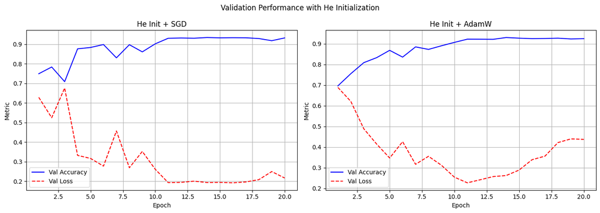

```python
import matplotlib.pyplot as plt
import pickle

# Load history logs
with open("vgg16_he_sgd_128_history.pkl", "rb") as f:
    sgd = pickle.load(f)

with open("vgg16_he_adamw_128_history.pkl", "rb") as f:
    adamw = pickle.load(f)

epochs = range(1, len(sgd["val_acc"]) + 1)

# Create side-by-side plots
fig, axes = plt.subplots(1, 2, figsize=(14, 5))

# Plot 1: He Init + SGD
axes[0].plot(epochs, sgd["val_acc"], label="Val Accuracy", color="blue")
axes[0].plot(epochs, sgd["val_loss"], label="Val Loss", color="red", linestyle="--")
axes[0].set_title("He Init + SGD")
axes[0].set_xlabel("Epoch")
axes[0].set_ylabel("Metric")
axes[0].legend()
axes[0].grid(True)

# Plot 2: He Init + AdamW
axes[1].plot(epochs, adamw["val_acc"], label="Val Accuracy", color="blue")
axes[1].plot(epochs, adamw["val_loss"], label="Val Loss", color="red", linestyle="--")
axes[1].set_title("He Init + AdamW")
axes[1].set_xlabel("Epoch")
axes[1].set_ylabel("Metric")
axes[1].legend()
axes[1].grid(True)

plt.suptitle("Validation Performance with He Initialization")
plt.tight_layout()
plt.show()
```

To assess the robustness of the He initialization strategy, we trained two VGG-16 models using the same architecture and batch size (128), but with different optimizers: SGD and AdamW.

This comparison isolates the effect of the optimizer while keeping initialization and data setup constant. As shown in the training logs and plotted validation curves, both models trained successfully and achieved high performance. The SGD-based model reached a validation accuracy of 93.47%, while the AdamW model reached 93.07%.

This reinforces the idea that choosing a well-suited weight initializer can improve model resilience and reduce sensitivity to optimizer choice, especially in deeper networks like VGG.

# Effect of Batch Size on Training Speed and Performance

To evaluate the impact of batch size on training time and performance, we compared experiments using batch sizes of 32, 64, and 128. As expected, models trained with larger batch sizes (128) completed training slightly faster (≈6.86–7.12 minutes), while batch size 32 took longer (≈9.08 minutes). This reflects the reduced number of parameter updates needed per epoch when using larger batches.

However, performance was not strictly tied to batch size. One of the best-performing models (vgg16_xavier_sgd_32_nodecay) with batch size 32 reached a validation accuracy of 93.51%, outperforming some models trained with batch size 64 or 128. Conversely, some batch size 64 configurations (e.g., with Adam) failed entirely, achieving only 33.33%. This confirms that batch size alone does not guarantee better generalization. Its interaction with the optimizer and learning rate plays a critical role.

In summary, while larger batch sizes offer faster training, a moderate batch size (like 32) may provide a better trade-off between stability and generalization, especially when paired with the right optimizer.

4. Apply regularization and overfitting prevention techniques.

# **Experiment 9:** Xavier Initialization + SGD Optimizer + Batch Size 32 + Regularization

```python
# Config
init = 'xavier'
optimizer_name = 'sgd'
batch_size = 32
model_name = "vgg16_xavier_sgd_32_reg"

# DataLoader
train_loader = DataLoader(train_dataset, batch_size=batch_size, shuffle=True)
val_loader = DataLoader(val_dataset, batch_size=batch_size)

# Model
model = VGG16Custom(num_classes=3).to(device)
model.apply(init_weights_xavier)

# Optimizer, Scheduler, Loss
optimizer = torch.optim.SGD(model.parameters(), lr=0.01, momentum=0.9, weight_decay=1e-4)  # now with weight decay
scheduler = torch.optim.lr_scheduler.StepLR(optimizer, step_size=10, gamma=0.1)
criterion = nn.CrossEntropyLoss()

#  Train
model, history = train_model(
    model=model,
    train_loader=train_loader,
    val_loader=val_loader,
    criterion=criterion,
    optimizer=optimizer,
    scheduler=scheduler,
    num_epochs=20,
    device=device,
    model_name=model_name
)
```

```
Epoch  1/20 | Train Loss: 0.8391 Train Acc: 0.5837 | Val Loss: 0.5793 Train Acc: 0.7756 | Time: 24.86s
Epoch  2/20 | Train Loss: 0.4937 Train Acc: 0.8071 | Val Loss: 0.4877 Train Acc: 0.8104 | Time: 24.77s
Epoch  3/20 | Train Loss: 0.4359 Train Acc: 0.8323 | Val Loss: 0.4084 Train Acc: 0.8436 | Time: 24.75s
Epoch  4/20 | Train Loss: 0.3786 Train Acc: 0.8554 | Val Loss: 0.3557 Train Acc: 0.8673 | Time: 24.77s
Epoch  5/20 | Train Loss: 0.3379 Train Acc: 0.8732 | Val Loss: 0.3562 Train Acc: 0.8707 | Time: 24.87s
Epoch  6/20 | Train Loss: 0.3020 Train Acc: 0.8884 | Val Loss: 0.2709 Train Acc: 0.9042 | Time: 24.73s
Epoch  7/20 | Train Loss: 0.2725 Train Acc: 0.8995 | Val Loss: 0.2791 Train Acc: 0.8940 | Time: 24.70s
Epoch  8/20 | Train Loss: 0.2539 Train Acc: 0.9080 | Val Loss: 0.2818 Train Acc: 0.9016 | Time: 24.64s
Epoch  9/20 | Train Loss: 0.2357 Train Acc: 0.9123 | Val Loss: 0.2356 Train Acc: 0.9151 | Time: 24.79s

Training complete in 8.26 minutes
Best Val Accuracy: 0.9376
Saved best model: vgg16_xavier_sgd_32_reg_best_model.pt
Saved training log: vgg16_xavier_sgd_32_reg_history.pkl
```

# **Image Augmentation**

```python
from torchvision import transforms, datasets
from torch.utils.data import DataLoader, Subset

# Augmented transform for training only
augmented_transform = transforms.Compose([
    transforms.RandomRotation(10),
    transforms.RandomAffine(degrees=0, translate=(0.1, 0.1), scale=(0.9, 1.1)),
    transforms.RandomHorizontalFlip(),
    transforms.Resize((64, 64)),
    transforms.ToTensor(),
    transforms.Normalize(mean, std),
])

# Validation and test transform (no augmentation)
fixed_transform = transforms.Compose([
    transforms.Resize((64, 64)),
    transforms.ToTensor(),
    transforms.Normalize(mean, std),
])

# Reload datasets
augmented_dataset = datasets.ImageFolder(root=data_dir, transform=augmented_transform)
fixed_dataset = datasets.ImageFolder(root=data_dir, transform=fixed_transform)

# Use same split indices
train_dataset_aug = Subset(augmented_dataset, train_indices)
val_dataset_fixed = Subset(fixed_dataset, val_indices)
test_dataset_fixed = Subset(fixed_dataset, test_indices)

# Dataloaders
train_loader_aug = DataLoader(train_dataset_aug, batch_size=32, shuffle=True)
val_loader_fixed = DataLoader(val_dataset_fixed, batch_size=32, shuffle=False)
test_loader_fixed = DataLoader(test_dataset_fixed, batch_size=32, shuffle=False)
```

# **Experiment 10:** Xavier Initialization + SGD Optimizer + Batch Size 32 + Image Augmentation

```python
model_name = "vgg16_xavier_sgd_32_aug"
model = VGG16Custom(num_classes=3).to(device)
model.apply(init_weights_xavier)

optimizer = torch.optim.SGD(model.parameters(), lr=0.01, momentum=0.9, weight_decay=0.0)
scheduler = torch.optim.lr_scheduler.StepLR(optimizer, step_size=10, gamma=0.1)
criterion = nn.CrossEntropyLoss()

model, history = train_model(
    model=model,
    train_loader=train_loader_aug,
    val_loader=val_loader_fixed,
    criterion=criterion,
    optimizer=optimizer,
    scheduler=scheduler,
    num_epochs=20,
    device=device,
    model_name=model_name
)
```

```
Epoch  1/20 | Train Loss: 0.7610 Train Acc: 0.6505 | Val Loss: 0.6601 Train Acc: 0.7124 | Time: 30.52s
Epoch  2/20 | Train Loss: 0.5306 Train Acc: 0.7905 | Val Loss: 0.4300 Train Acc: 0.8318 | Time: 30.79s
Epoch  3/20 | Train Loss: 0.4545 Train Acc: 0.8261 | Val Loss: 0.4142 Train Acc: 0.8393 | Time: 30.66s
Epoch  4/20 | Train Loss: 0.4004 Train Acc: 0.8493 | Val Loss: 0.3367 Train Acc: 0.8742 | Time: 30.37s
Epoch  5/20 | Train Loss: 0.3581 Train Acc: 0.8669 | Val Loss: 0.3024 Train Acc: 0.8891 | Time: 30.25s
Epoch  6/20 | Train Loss: 0.3366 Train Acc: 0.8730 | Val Loss: 0.2813 Train Acc: 0.8958 | Time: 30.62s
Epoch  7/20 | Train Loss: 0.3191 Train Acc: 0.8832 | Val Loss: 0.2700 Train Acc: 0.8987 | Time: 30.38s
Epoch  8/20 | Train Loss: 0.2979 Train Acc: 0.8894 | Val Loss: 0.2849 Train Acc: 0.9042 | Time: 30.29s
Epoch  9/20 | Train Loss: 0.2917 Train Acc: 0.8930 | Val Loss: 0.3056 Train Acc: 0.8838 | Time: 30.27s

Training complete in 10.14 minutes
Best Val Accuracy: 0.9376
Saved best model: vgg16_xavier_sgd_32_aug_best_model.pt
Saved training log: vgg16_xavier_sgd_32_aug_history.pkl
```

# **Xavier Initialization + SGD Optimizer + Batch Size 32 + Image Augmentation + Regularization**

```python
# Config
model_name = "vgg16_xavier_sgd_32_aug_reg"
batch_size = 32

# Reuse transforms from previous runs
# train_loader_aug already includes image augmentation
# val_loader_fixed remains the same

# Model
model = VGG16Custom(num_classes=3).to(device)
model.apply(init_weights_xavier)

# Optimizer with weight decay
optimizer = torch.optim.SGD(model.parameters(), lr=0.01, momentum=0.9, weight_decay=1e-4)
scheduler = torch.optim.lr_scheduler.StepLR(optimizer, step_size=10, gamma=0.1)
criterion = nn.CrossEntropyLoss()

# Train
model, history = train_model(
    model=model,
    train_loader=train_loader_aug,         # augmented data
    val_loader=val_loader_fixed,           # clean validation
    criterion=criterion,
    optimizer=optimizer,
    scheduler=scheduler,
    num_epochs=20,
    device=device,
    model_name=model_name
)
```

```
Epoch  1/20 | Train Loss: 0.7261 Train Acc: 0.6685 | Val Loss: 0.4670 Train Acc: 0.8173 | Time: 30.48s
Epoch  2/20 | Train Loss: 0.5186 Train Acc: 0.8001 | Val Loss: 0.5080 Train Acc: 0.8082 | Time: 30.42s
Epoch  3/20 | Train Loss: 0.4404 Train Acc: 0.8320 | Val Loss: 0.3760 Train Acc: 0.8556 | Time: 30.43s
Epoch  4/20 | Train Loss: 0.3925 Train Acc: 0.8539 | Val Loss: 0.3857 Train Acc: 0.8576 | Time: 30.55s
Epoch  5/20 | Train Loss: 0.3651 Train Acc: 0.8640 | Val Loss: 0.3615 Train Acc: 0.8700 | Time: 30.42s
Epoch  6/20 | Train Loss: 0.3386 Train Acc: 0.8741 | Val Loss: 0.3390 Train Acc: 0.8782 | Time: 30.39s
Epoch  7/20 | Train Loss: 0.3116 Train Acc: 0.8849 | Val Loss: 0.2882 Train Acc: 0.8962 | Time: 30.63s
Epoch  8/20 | Train Loss: 0.2934 Train Acc: 0.8925 | Val Loss: 0.2732 Train Acc: 0.9004 | Time: 30.51s
Epoch  9/20 | Train Loss: 0.2915 Train Acc: 0.8922 | Val Loss: 0.2487 Train Acc: 0.9100 | Time: 30.49s

Training complete in 10.16 minutes
Best Val Accuracy: 0.9393
Saved best model: vgg16_xavier_sgd_32_aug_reg_best_model.pt
Saved training log: vgg16_xavier_sgd_32_aug_reg_history.pkl
```

# Best Model : Val Accuracy & Val Loss

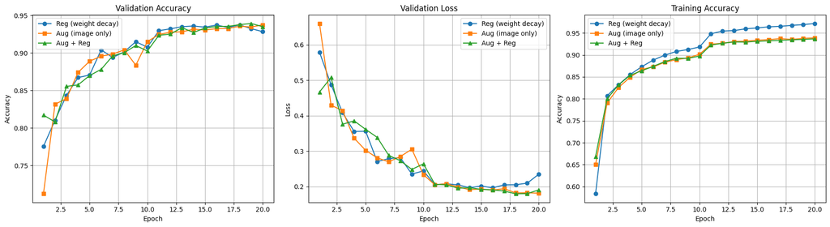

```python
import matplotlib.pyplot as plt
import pickle

# Load history logs
with open("vgg16_xavier_sgd_32_reg_history.pkl", "rb") as f:
    reg = pickle.load(f)

with open("vgg16_xavier_sgd_32_aug_history.pkl", "rb") as f:
    aug = pickle.load(f)

with open("vgg16_xavier_sgd_32_aug_reg_history.pkl", "rb") as f:
    aug_reg = pickle.load(f)

# Plot
epochs = range(1, len(reg["val_acc"]) + 1)
plt.figure(figsize=(18, 5))

# 1. Validation Accuracy
plt.subplot(1, 3, 1)
plt.plot(epochs, reg["val_acc"], label="Reg (weight decay)", marker='o')
plt.plot(epochs, aug["val_acc"], label="Aug (image only)", marker='s')
plt.plot(epochs, aug_reg["val_acc"], label="Aug + Reg", marker='^')
plt.title("Validation Accuracy")
plt.xlabel("Epoch")
plt.ylabel("Accuracy")
plt.grid(True)
plt.legend()

# 2. Validation Loss
plt.subplot(1, 3, 2)
plt.plot(epochs, reg["val_loss"], label="Reg (weight decay)", marker='o')
plt.plot(epochs, aug["val_loss"], label="Aug (image only)", marker='s')
plt.plot(epochs, aug_reg["val_loss"], label="Aug + Reg", marker='^')
plt.title("Validation Loss")
plt.xlabel("Epoch")
plt.ylabel("Loss")
plt.grid(True)
plt.legend()

# 3. Training Accuracy
plt.subplot(1, 3, 3)
plt.plot(epochs, reg["train_acc"], label="Reg (weight decay)", marker='o')
plt.plot(epochs, aug["train_acc"], label="Aug (image only)", marker='s')
plt.plot(epochs, aug_reg["train_acc"], label="Aug + Reg", marker='^')
plt.title("Training Accuracy")
plt.xlabel("Epoch")
plt.ylabel("Accuracy")
plt.grid(True)
plt.legend()

plt.tight_layout()
plt.show()
```

To improve generalization and reduce overfitting, we applied and compared two widely used overfitting control techniques to the best-performing model from Step 3 `(VGG16 + Xavier Init + SGD + Batch Size 32)`:

**Techniques Applied**

- **L2 Regularization (Weight Decay)** Added a `weight_decay=1e-4` term to the SGD optimizer. This penalizes large weights and encourages simpler models.
- **Image Augmentation** Introduced random rotation, affine transformations, and horizontal flipping to artificially diversify the training dataset and improve robustness.

Both regularization techniques were effective in reducing overfitting and improving generalization. While each method alone provided strong results, combining image augmentation and weight decay produced the best validation performance overall. Therefore, this combined model `(vgg16_xavier_sgd_32_aug_reg)` is selected for final evaluation on the test set.

5. Evaluation and analysis.

Load best model

```python
model = VGG16Custom(num_classes=3).to(device)
model.load_state_dict(torch.load("vgg16_xavier_sgd_32_aug_reg_best_model.pt"))
model.eval()
```

Evaluate the model with test dataset

```python
from sklearn.metrics import accuracy_score, confusion_matrix, precision_recall_fscore_support
import torch.nn.functional as F

# Collect predictions and true labels
all_preds = []
all_labels = []
test_loss = 0.0

with torch.no_grad():
    for images, labels in test_loader_fixed:
        images, labels = images.to(device), labels.to(device)
        outputs = model(images)
        loss = criterion(outputs, labels)
        test_loss += loss.item() * labels.size(0)

        _, preds = torch.max(outputs, 1)
        all_preds.extend(preds.cpu().numpy())
        all_labels.extend(labels.cpu().numpy())

test_loss /= len(test_loader_fixed.dataset)
test_acc = accuracy_score(all_labels, all_preds)
```

Training accuracy, training loss, validation accuracy, validation loss, testing accuracy, and testing loss. Provide your short analysis.

```python
import pickle

with open("vgg16_xavier_sgd_32_aug_reg_history.pkl", "rb") as f:
    hist = pickle.load(f)

# Extract final values
train_acc = hist["train_acc"][-1]
train_loss = hist["train_loss"][-1]
val_acc = hist["val_acc"][-1]
val_loss = hist["val_loss"][-1]

print(f"Training Accuracy   : {train_acc:.4f}")
print(f"Training Loss       : {train_loss:.4f}")
print(f"Validation Accuracy : {val_acc:.4f}")
print(f"Validation Loss     : {val_loss:.4f}")
print(f"Test Accuracy       : {test_acc:.4f}")
print(f"Test Loss           : {test_loss:.4f}")
print(f"Test Accuracy       : {test_acc:.4f}")
print(f"Test Loss           : {test_loss:.4f}")
```

```
Training Accuracy   : 0.9365
Training Loss       : 0.1753
Validation Accuracy : 0.9351
Validation Loss     : 0.1909
Test Accuracy       : 0.9338
Test Loss           : 0.1793
Test Accuracy       : 0.9338
Test Loss           : 0.1793
```

The model exhibits strong generalization, with training, validation, and test accuracies all around 93–94%, and no signs of overfitting. The training loss is slightly lower than the validation/test loss, which can be expected. The close alignment between validation and test accuracy indicates that the model performs reliably on unseen data, confirming the effectiveness of the regularization and augmentation strategies used.

- Plot the training and validation accuracy over time (epochs).
- Plot the training and validation loss over time (epochs).

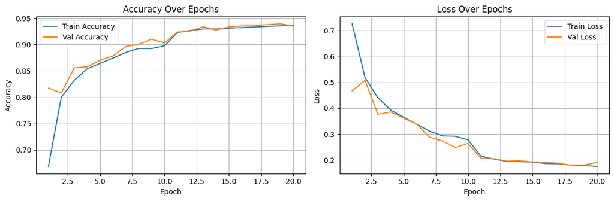

```python
import pickle
import matplotlib.pyplot as plt

with open("vgg16_xavier_sgd_32_aug_reg_history.pkl", "rb") as f:
    hist = pickle.load(f)

epochs = range(1, len(hist["train_acc"]) + 1)

# Accuracy Plot
plt.figure(figsize=(12, 4))
plt.subplot(1, 2, 1)
plt.plot(epochs, hist["train_acc"], label="Train Accuracy")
plt.plot(epochs, hist["val_acc"], label="Val Accuracy")
plt.xlabel("Epoch")
plt.ylabel("Accuracy")
plt.title("Accuracy Over Epochs")
plt.grid(True)
plt.legend()

# Loss Plot
plt.subplot(1, 2, 2)
plt.plot(epochs, hist["train_loss"], label="Train Loss")
plt.plot(epochs, hist["val_loss"], label="Val Loss")
plt.xlabel("Epoch")
plt.ylabel("Loss")
plt.title("Loss Over Epochs")
plt.grid(True)
plt.legend()

plt.tight_layout()
plt.show()
```

- Generate a confusion matrix for the test set using sklearn.metrics.confusion_matrix. Display it using seaborn.heatmap. Analyze the confusion matrix: Which classes are most often confused?

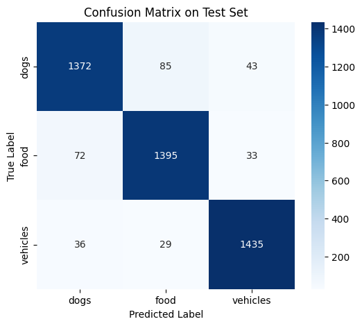

```python
import seaborn as sns
import numpy as np
from sklearn.metrics import ConfusionMatrixDisplay

cm = confusion_matrix(all_labels, all_preds)
plt.figure(figsize=(6, 5))
sns.heatmap(cm, annot=True, fmt="d", cmap="Blues", xticklabels=dataset.classes, yticklabels=dataset.classes)
plt.title("Confusion Matrix on Test Set")
plt.xlabel("Predicted Label")
plt.ylabel("True Label")
plt.show()
```

The model performs very well across all classes, with over 1370 correct predictions per class.

Dogs ↔ Food is the most common confusion:

- 85 images of dogs were misclassified as food
- 72 images of food were misclassified as dogs

Vehicles are the most distinct class:

Misclassifications may arise due to visual similarity (e.g., color, shape, or background clutter).

- Calculate and report other evaluation metrics such as precision, recall and F1 score

```python
precision, recall, f1, _ = precision_recall_fscore_support(all_labels, all_preds, average=None, labels=[0, 1, 2])

for idx, cls in enumerate(dataset.classes):
    print(f"\nClass: {cls}")
    print(f"  Precision: {precision[idx]:.4f}")
    print(f"  Recall:    {recall[idx]:.4f}")
    print(f"  F1 Score:  {f1[idx]:.4f}")
```

```
Class: dogs
  Precision: 0.9270
  Recall:    0.9147
  F1 Score:  0.9208

Class: food
  Precision: 0.9245
  Recall:    0.9300
  F1 Score:  0.9272

Class: vehicles
  Precision: 0.9497
  Recall:    0.9567
  F1 Score:  0.9532
```

Dogs:

- Precision (92.7%) is slightly higher than recall (91.5%), indicating that the model is slightly more cautious and makes fewer false positives for this class.

Food:

- Balanced performance: Precision and recall are nearly identical (~92.5–93%), resulting in a solid F1 score of 92.7%.

Vehicles:

- Best performance overall: Precision and recall both exceed 94%, with the highest F1 score (95.3%). This matches what we observed in the confusion matrix — vehicles are the easiest to distinguish.

- Display a few misclassified images from the test set along with their predicted and true labels. Try to explain why the model might have made these mistakes.

[figure not shown]

```python
import random

misclassified = []

with torch.no_grad():
    for images, labels in test_loader_fixed:
        images, labels = images.to(device), labels.to(device)
        outputs = model(images)
        _, preds = torch.max(outputs, 1)
        for img, pred, label in zip(images, preds, labels):
            if pred != label:
                misclassified.append((img.cpu(), pred.item(), label.item()))

# Display a few
plt.figure(figsize=(10, 6))
for i in range(6):
    img, pred, label = random.choice(misclassified)
    plt.subplot(2, 3, i + 1)
    img = img * std + mean  # unnormalize (use float values)
    plt.imshow(img.permute(1, 2, 0).squeeze(), cmap='gray')
    plt.title(f"True: {dataset.classes[label]}\nPred: {dataset.classes[pred]}")
    plt.axis('off')

plt.tight_layout()
plt.show()
```

(Img 1 & 4) **Dogs → Food:** In these images, the dogs are camouflaged, with some of their body parts covered, making them unrecognizable. It doesn't resemble a vehicle, which is why it is misclassified.

(Img 2) **Dogs → Food:** It seems like an animal statute kept on a plate, kind of a stand placed on a white table. Even the human eye could not identify it at first glance. The model might have identified some food served on a plate at the table.

(Img 3) **Dogs → Vehicles:** In this case, the dog has been identified as a vehicle, and this could be justified. The image features a car in the distance, which is white, and the dog is lying on the ground at a different angle, leading to its categorization as a vehicle.

(Img 5) **Food → Vehicles:** In this instance, a chocolate syrup bottle has been incorrectly classified as a vehicle. This misclassification may be due to the bottle's shape and colour. Additionally, the image's background might be misleading, contributing to the confusion.

(Img 6) **Food → Dogs:** The image mistakenly classifies food as a dog presents dark and brown-coloured food. Only part of the food is visible, and it doesn't resemble a vehicle, which likely led the model to misclassify it as a dog.

6. Save the weights of the trained network.

```python
# Reload the best saved weights from training
model = VGG16Custom(num_classes=3).to(device)
model.load_state_dict(torch.load("vgg16_xavier_sgd_32_aug_reg_best_model.pt"))
model.eval()

torch.save(model.state_dict(), "a1_part2_vgg_ellawela.pt")
print("Model saved as a1_part2_vgg_ellawela.pt")
```

```
Model saved as a1_part2_vgg_ellawela.pt
```

## Step 3: Implementing ResNet

1. Implement residual blocks of ResNet.

```python
import torch
import torch.nn as nn

class ResidualBlock(nn.Module):
    def __init__(self, in_channels, out_channels, stride=1, downsample=None):
        super(ResidualBlock, self).__init__()
        # First convolutional layer with batch normalization and ReLU
        self.conv1 = nn.Conv2d(in_channels, out_channels, kernel_size=3, stride=stride, padding=1, bias=False)
        self.bn1 = nn.BatchNorm2d(out_channels)
        self.relu = nn.ReLU(inplace=True)
        # Second convolutional layer with batch normalization
        self.conv2 = nn.Conv2d(out_channels, out_channels, kernel_size=3, padding=1, bias=False)
        self.bn2 = nn.BatchNorm2d(out_channels)
        # downsample operation for the identity path
        self.downsample = downsample

    def forward(self, x):
        identity = x # Save the original input for the skip connection

        # If dimensions differ, apply downsampling to identity
        if self.downsample is not None:
            identity = self.downsample(x)

        # Forward pass through two conv-bn layers with ReLU in between
        out = self.relu(self.bn1(self.conv1(x)))
        out = self.bn2(self.conv2(out))
        # Add skip connection
        out += identity
        # Final activation
        return self.relu(out)
```

2. Assemble the ResNet-18 architecture.

```python
class ResNet18(nn.Module):
    def __init__(self, block, layers, num_classes=3):
        super(ResNet18, self).__init__()
        self.in_channels = 64

        # Initial convolution + batch norm + ReLU + max pooling
        self.conv1 = nn.Conv2d(3, 64, kernel_size=7, stride=2, padding=3, bias=False)  # initial conv
        self.bn1 = nn.BatchNorm2d(64)
        self.relu = nn.ReLU(inplace=True)
        self.maxpool = nn.MaxPool2d(kernel_size=3, stride=2, padding=1)

        # Residual block layers
        self.layer1 = self._make_layer(block, 64,  layers[0])           # Output: same spatial size
        self.layer2 = self._make_layer(block, 128, layers[1], stride=2) # Output spatial size halved
        self.layer3 = self._make_layer(block, 256, layers[2], stride=2)
        self.layer4 = self._make_layer(block, 512, layers[3], stride=2)
        # Global average pooling
        self.avgpool = nn.AdaptiveAvgPool2d((1, 1))

        # Regularization to reduce overfitting
        self.dropout = nn.Dropout(0.5) # added dropout to VGG as well

         # Final fully connected layer
        self.fc = nn.Linear(512, num_classes)

    def _make_layer(self, block, out_channels, blocks, stride=1):
        # Handle downsampling when input and output dimensions differ
        downsample = None
        if stride != 1 or self.in_channels != out_channels:
            downsample = nn.Sequential(
                nn.Conv2d(self.in_channels, out_channels, kernel_size=1, stride=stride, bias=False),
                nn.BatchNorm2d(out_channels)
            )

        # First block may involve downsampling
        layers = [block(self.in_channels, out_channels, stride, downsample)]
        self.in_channels = out_channels
        # Remaining blocks
        for _ in range(1, blocks):
            layers.append(block(out_channels, out_channels))

        return nn.Sequential(*layers)

    def forward(self, x):
        # Initial layers
        x = self.relu(self.bn1(self.conv1(x)))
        x = self.maxpool(x)

        # Residual layers
        x = self.layer1(x)
        x = self.layer2(x)
        x = self.layer3(x)
        x = self.layer4(x)

        # Classification head
        x = self.avgpool(x)
        x = torch.flatten(x, 1)
        x = self.dropout(x)
        x = x.view(x.size(0), -1)
        return self.fc(x)
```

3. Train the ResNet-18 model.

Training Loop

```python
import time
import copy
import pickle
from torch import nn

def train_model(model, train_loader, val_loader, criterion, optimizer,
                scheduler, num_epochs, device, model_name):
    # Start total training timer
    since = time.time()

    # Track the best model weights and accuracy
    best_model_wts = copy.deepcopy(model.state_dict())
    best_acc = 0.0

    # Lists to store loss and accuracy values for each epoch
    train_loss_history = []
    val_loss_history = []
    train_acc_history = []
    val_acc_history = []

    for epoch in range(num_epochs):
        epoch_start = time.time()
        model.train() # Set model to training mode

        # Initialize training metrics
        train_loss = 0.0
        train_correct = 0
        train_total = 0

        # --- Training loop ---
        for inputs, labels in train_loader:
            inputs, labels = inputs.to(device), labels.to(device)

            optimizer.zero_grad()             # Reset gradients
            outputs = model(inputs)           # Forward pass
            _, preds = torch.max(outputs, 1)  # Predictions
            loss = criterion(outputs, labels) # Compute loss
            loss.backward()                   # Backpropagation
            optimizer.step()                  # Update weights

            train_loss += loss.item() * inputs.size(0)
            train_correct += (preds == labels).sum().item()
            train_total += labels.size(0)

        # Compute average training metrics
        train_loss /= train_total
        train_acc = train_correct / train_total
        train_loss_history.append(train_loss)
        train_acc_history.append(train_acc)

        # --- Validation loop ---
        model.eval()
        val_loss = 0.0
        val_correct = 0
        val_total = 0

        with torch.no_grad():
            for inputs, labels in val_loader:
                inputs, labels = inputs.to(device), labels.to(device)
                outputs = model(inputs)
                _, preds = torch.max(outputs, 1)
                loss = criterion(outputs, labels)
                val_loss += loss.item() * inputs.size(0)
                val_correct += (preds == labels).sum().item()
                val_total += labels.size(0)

        # Compute average validation metrics
        val_loss /= val_total
        val_acc = val_correct / val_total
        val_loss_history.append(val_loss)
        val_acc_history.append(val_acc)

        # Update best model if current validation accuracy is higher
        if val_acc > best_acc:
            best_acc = val_acc
            best_model_wts = copy.deepcopy(model.state_dict())

        # Update scheduler if used
        if scheduler:
            scheduler.step()

        # Epoch summary
        epoch_end = time.time()
        print(f"Epoch {epoch+1:2d}/{num_epochs} | "
              f"Train Loss: {train_loss:.4f} Acc: {train_acc:.4f} | "
              f"Val Loss: {val_loss:.4f} Acc: {val_acc:.4f} | "
              f"Time: {epoch_end - epoch_start:.2f}s")

    # Final training summary
    total_time = time.time() - since
    print(f"\nTraining complete in {total_time / 60:.2f} minutes")
    print(f"Best Val Accuracy: {best_acc:.4f}")

    # Save best model weights and training history
    if model_name:
        torch.save(best_model_wts, f"{model_name}_best_model.pt")
        print(f"Saved best model as: {model_name}_best_model.pt")

        history = {
            'train_loss': train_loss_history,
            'val_loss': val_loss_history,
            'train_acc': train_acc_history,
            'val_acc': val_acc_history,
            'best_val_acc': best_acc
        }

        with open(f"{model_name}_history.pkl", 'wb') as f:
            pickle.dump(history, f)
        print(f"Saved training log as: {model_name}_history.pkl")

    # Load best model weights before returning
    model.load_state_dict(best_model_wts)
    return model, history
```

weight initialization strategies

```python
def init_weights_xavier(m):
    if isinstance(m, nn.Conv2d) or isinstance(m, nn.Linear):
        nn.init.xavier_uniform_(m.weight)

def init_weights_he(m):
    if isinstance(m, nn.Conv2d) or isinstance(m, nn.Linear):
        nn.init.kaiming_normal_(m.weight, nonlinearity='relu')
```

# **Experiment 1:** ResNet-18 with Xavier Initialization

```python
import torch
import torch.nn as nn
import torch.optim as optim

# Xavier Initialization Run

torch.manual_seed(1227)
device = torch.device("cuda" if torch.cuda.is_available() else "cpu")
criterion = nn.CrossEntropyLoss()

# DataLoader
train_loader = DataLoader(train_dataset, batch_size=32, shuffle=True)
val_loader = DataLoader(val_dataset, batch_size=32)
test_loader = DataLoader(test_dataset, batch_size=32, shuffle=False)


# Model + init
model_xavier = ResNet18(ResidualBlock, [2, 2, 2, 2], num_classes=3)
model_xavier.apply(init_weights_xavier)
model_xavier = model_xavier.to(device)

# Optimizer + scheduler
optimizer_xavier = optim.Adam(model_xavier.parameters(), lr=0.001)
scheduler_xavier = optim.lr_scheduler.StepLR(optimizer_xavier, step_size=10, gamma=0.5)

# Train and save best model + history
model_xavier_best, history_xavier = train_model(
    model_xavier,
    train_loader,
    val_loader,
    criterion,
    optimizer_xavier,
    scheduler_xavier,
    num_epochs=20,
    device=device,
    model_name="resnet18_xavier"
)
```

```
Epoch  1/20 | Train Loss: 0.5483 Acc: 0.7986 | Val Loss: 0.3964 Acc: 0.8560 | Time: 21.85s
Epoch  2/20 | Train Loss: 0.3779 Acc: 0.8580 | Val Loss: 0.3333 Acc: 0.8722 | Time: 22.00s
Epoch  3/20 | Train Loss: 0.3170 Acc: 0.8805 | Val Loss: 0.3121 Acc: 0.8849 | Time: 21.43s
Epoch  4/20 | Train Loss: 0.2851 Acc: 0.8919 | Val Loss: 0.3028 Acc: 0.8958 | Time: 21.75s
Epoch  5/20 | Train Loss: 0.2546 Acc: 0.9038 | Val Loss: 0.2733 Acc: 0.8982 | Time: 22.70s
Epoch  6/20 | Train Loss: 0.2678 Acc: 0.9052 | Val Loss: 0.2737 Acc: 0.9049 | Time: 22.68s
Epoch  7/20 | Train Loss: 0.2085 Acc: 0.9234 | Val Loss: 0.2434 Acc: 0.9111 | Time: 22.71s
Epoch  8/20 | Train Loss: 0.1907 Acc: 0.9286 | Val Loss: 0.2292 Acc: 0.9200 | Time: 22.67s
Epoch  9/20 | Train Loss: 0.1681 Acc: 0.9379 | Val Loss: 0.2522 Acc: 0.9093 | Time: 22.58s

Training complete in 7.34 minutes
Best Val Accuracy: 0.9278
Saved best model as: resnet18_xavier_best_model.pt
Saved training log as: resnet18_xavier_history.pkl
```

# **Experiment 2:** ResNet-18 with He Initialization

```python
# He Initialization Run

torch.manual_seed(1227)
device = torch.device("cuda" if torch.cuda.is_available() else "cpu")
criterion = nn.CrossEntropyLoss()

# DataLoader (reuse same split)
train_loader = DataLoader(train_dataset, batch_size=32, shuffle=True)
val_loader = DataLoader(val_dataset, batch_size=32)

# Model + init
model_he = ResNet18(ResidualBlock, [2, 2, 2, 2], num_classes=3)
model_he.apply(init_weights_he)
model_he = model_he.to(device)

# Optimizer + scheduler
optimizer_he = optim.Adam(model_he.parameters(), lr=0.001)
scheduler_he = optim.lr_scheduler.StepLR(optimizer_he, step_size=10, gamma=0.5)

# Train and save best model + history
model_he_best, history_he = train_model(
    model_he,
    train_loader,
    val_loader,
    criterion,
    optimizer_he,
    scheduler_he,
    num_epochs=20,
    device=device,
    model_name="resnet18_he"
)
```

```
Epoch  1/20 | Train Loss: 0.5043 Acc: 0.8168 | Val Loss: 0.5034 Acc: 0.8287 | Time: 22.05s
Epoch  2/20 | Train Loss: 0.3258 Acc: 0.8788 | Val Loss: 0.3342 Acc: 0.8760 | Time: 21.39s
Epoch  3/20 | Train Loss: 0.2839 Acc: 0.8955 | Val Loss: 0.2739 Acc: 0.9051 | Time: 21.87s
Epoch  4/20 | Train Loss: 0.2364 Acc: 0.9132 | Val Loss: 0.4186 Acc: 0.8502 | Time: 21.92s
Epoch  5/20 | Train Loss: 0.2197 Acc: 0.9181 | Val Loss: 0.3704 Acc: 0.8660 | Time: 21.56s
Epoch  6/20 | Train Loss: 0.2206 Acc: 0.9207 | Val Loss: 0.2425 Acc: 0.9149 | Time: 22.14s
Epoch  7/20 | Train Loss: 0.1705 Acc: 0.9369 | Val Loss: 0.2883 Acc: 0.9036 | Time: 21.67s
Epoch  8/20 | Train Loss: 0.1533 Acc: 0.9440 | Val Loss: 0.2094 Acc: 0.9304 | Time: 21.93s
Epoch  9/20 | Train Loss: 0.1210 Acc: 0.9546 | Val Loss: 0.2472 Acc: 0.9193 | Time: 21.95s

Training complete in 7.31 minutes
Best Val Accuracy: 0.9311
Saved best model as: resnet18_he_best_model.pt
Saved training log as: resnet18_he_history.pkl
```

# Compare He vs Xavier Initialization

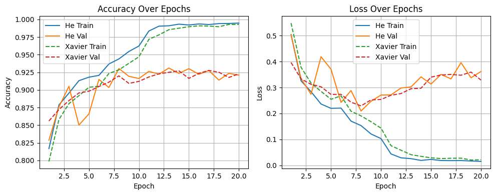

```python
import pickle
import matplotlib.pyplot as plt

# Load training histories
with open("resnet18_he_history.pkl", "rb") as f:
    he = pickle.load(f)

with open("resnet18_xavier_history.pkl", "rb") as f:
    xavier = pickle.load(f)

epochs = range(1, len(he['train_acc']) + 1)

# Accuracy Plot
plt.figure(figsize=(10, 4))
plt.subplot(1, 2, 1)
plt.plot(epochs, he['train_acc'], label="He Train")
plt.plot(epochs, he['val_acc'], label="He Val")
plt.plot(epochs, xavier['train_acc'], label="Xavier Train", linestyle="--")
plt.plot(epochs, xavier['val_acc'], label="Xavier Val", linestyle="--")
plt.title("Accuracy Over Epochs")
plt.xlabel("Epoch")
plt.ylabel("Accuracy")
plt.legend()
plt.grid(True)

# Loss Plot
plt.subplot(1, 2, 2)
plt.plot(epochs, he['train_loss'], label="He Train")
plt.plot(epochs, he['val_loss'], label="He Val")
plt.plot(epochs, xavier['train_loss'], label="Xavier Train", linestyle="--")
plt.plot(epochs, xavier['val_loss'], label="Xavier Val", linestyle="--")
plt.title("Loss Over Epochs")
plt.xlabel("Epoch")
plt.ylabel("Loss")
plt.legend()
plt.grid(True)

plt.tight_layout()
plt.show()
```

4. Apply regularization techniques.
- Both dropout and learning rate scheduler are applied.

# **Image Augmentation + Regularization**

```python
from torchvision import transforms, datasets
from torch.utils.data import DataLoader, Subset

# Augmented transform for training only
augmented_transform = transforms.Compose([
    transforms.RandomRotation(10),
    transforms.RandomAffine(degrees=0, translate=(0.1, 0.1), scale=(0.9, 1.1)),
    transforms.RandomHorizontalFlip(),
    transforms.Resize((64, 64)),
    transforms.ToTensor(),
    transforms.Normalize(mean, std),
])

# Validation and test transform (no augmentation)
fixed_transform = transforms.Compose([
    transforms.Resize((64, 64)),
    transforms.ToTensor(),
    transforms.Normalize(mean, std),
])

# Reload datasets
augmented_dataset = datasets.ImageFolder(root=data_dir, transform=augmented_transform)
fixed_dataset = datasets.ImageFolder(root=data_dir, transform=fixed_transform)

# Use same split indices
train_dataset_aug = Subset(augmented_dataset, train_indices)
val_dataset_fixed = Subset(fixed_dataset, val_indices)
test_dataset_fixed = Subset(fixed_dataset, test_indices)

# Dataloaders
train_loader_aug = DataLoader(train_dataset_aug, batch_size=32, shuffle=True)
val_loader_fixed = DataLoader(val_dataset_fixed, batch_size=32, shuffle=False)
test_loader_fixed = DataLoader(test_dataset_fixed, batch_size=32, shuffle=False)
```

# **Experiment 3:** ResNet-18 with He Initialization + Image Augmentation + Regularization

```python
# Model + He init
model_he_aug = ResNet18(ResidualBlock, [2, 2, 2, 2], num_classes=3)
model_he_aug.apply(init_weights_he)
model_he_aug = model_he_aug.to(device)

# Optimizer + LR scheduler + Regularization
optimizer_he_aug = optim.Adam(model_he_aug.parameters(), lr=0.001, weight_decay=1e-4)
scheduler_he_aug = optim.lr_scheduler.StepLR(optimizer_he_aug, step_size=10, gamma=0.5)

# Train and save best model with augmented data
model_he_aug_best, history_he_aug = train_model(
    model=model_he_aug,
    train_loader=train_loader_aug,
    val_loader=val_loader_fixed,
    criterion=criterion,
    optimizer=optimizer_he_aug,
    scheduler=scheduler_he_aug,
    num_epochs=20,
    device=device,
    model_name="resnet18_he_aug"
)
```

```
Epoch  1/20 | Train Loss: 0.5843 Acc: 0.7841 | Val Loss: 0.3952 Acc: 0.8573 | Time: 27.33s
Epoch  2/20 | Train Loss: 0.4089 Acc: 0.8476 | Val Loss: 0.3426 Acc: 0.8762 | Time: 27.70s
Epoch  3/20 | Train Loss: 0.3594 Acc: 0.8653 | Val Loss: 0.2912 Acc: 0.8898 | Time: 27.73s
Epoch  4/20 | Train Loss: 0.3463 Acc: 0.8727 | Val Loss: 0.2679 Acc: 0.9058 | Time: 27.53s
Epoch  5/20 | Train Loss: 0.3124 Acc: 0.8849 | Val Loss: 0.2664 Acc: 0.9053 | Time: 27.36s
Epoch  6/20 | Train Loss: 0.2966 Acc: 0.8924 | Val Loss: 0.2360 Acc: 0.9171 | Time: 27.00s
Epoch  7/20 | Train Loss: 0.2794 Acc: 0.8990 | Val Loss: 0.2439 Acc: 0.9167 | Time: 26.99s
Epoch  8/20 | Train Loss: 0.2816 Acc: 0.8971 | Val Loss: 0.2393 Acc: 0.9227 | Time: 27.23s
Epoch  9/20 | Train Loss: 0.2652 Acc: 0.9022 | Val Loss: 0.2059 Acc: 0.9247 | Time: 27.20s

Training complete in 9.05 minutes
Best Val Accuracy: 0.9444
Saved best model as: resnet18_he_aug_best_model.pt
Saved training log as: resnet18_he_aug_history.pkl
```

5. Evaluation and analysis.

Load the Best Model

```python
model = ResNet18(ResidualBlock, [2, 2, 2, 2], num_classes=3).to(device)
model.load_state_dict(torch.load("resnet18_he_aug_best_model.pt"))
model.eval()
```

Evaluate on Test Set

```python
from sklearn.metrics import accuracy_score, confusion_matrix, precision_recall_fscore_support
import torch.nn.functional as F

all_preds = []
all_labels = []
test_loss = 0.0

with torch.no_grad():
    for images, labels in test_loader_fixed:
        images, labels = images.to(device), labels.to(device)
        outputs = model(images)
        loss = criterion(outputs, labels)
        test_loss += loss.item() * labels.size(0)

        _, preds = torch.max(outputs, 1)
        all_preds.extend(preds.cpu().numpy())
        all_labels.extend(labels.cpu().numpy())

test_loss /= len(test_loader_fixed.dataset)
test_acc = accuracy_score(all_labels, all_preds)
precision, recall, f1, _ = precision_recall_fscore_support(all_labels, all_preds, average='weighted')
```

Load Training History & Print Final Metrics

```python
import pickle

with open("resnet18_he_aug_history.pkl", "rb") as f:
    hist = pickle.load(f)

train_acc = hist["train_acc"][-1]
train_loss = hist["train_loss"][-1]
val_acc = hist["val_acc"][-1]
val_loss = hist["val_loss"][-1]

print(f"Training Accuracy   : {train_acc:.4f}")
print(f"Training Loss       : {train_loss:.4f}")
print(f"Validation Accuracy : {val_acc:.4f}")
print(f"Validation Loss     : {val_loss:.4f}")
print(f"Test Accuracy       : {test_acc:.4f}")
print(f"Test Loss           : {test_loss:.4f}")
```

```
Training Accuracy   : 0.9377
Training Loss       : 0.1665
Validation Accuracy : 0.9444
Validation Loss     : 0.1511
Test Accuracy       : 0.9496
Test Loss           : 0.1354
```

The final ResNet-18 model with He initialization and image augmentation achieved strong results, with 94.44% validation accuracy and 94.96% test accuracy, outperforming all previous configurations. The low and consistent losses across training (0.1665), validation (0.1511), and test (0.1354) indicate excellent generalization. Regularization techniques such as dropout, learning rate scheduling, and augmentation effectively reduced overfitting. This version demonstrated the most stable and accurate performance, making it the best model overall.

Plot Accuracy & Loss Over Epochs

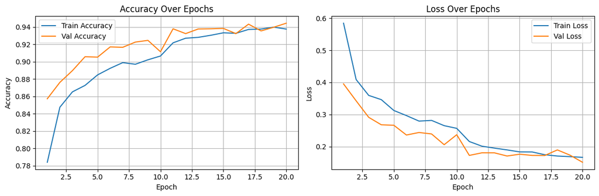

```python
import matplotlib.pyplot as plt

epochs = range(1, len(hist["train_acc"]) + 1)

plt.figure(figsize=(12, 4))

# Accuracy
plt.subplot(1, 2, 1)
plt.plot(epochs, hist["train_acc"], label="Train Accuracy")
plt.plot(epochs, hist["val_acc"], label="Val Accuracy")
plt.title("Accuracy Over Epochs")
plt.xlabel("Epoch")
plt.ylabel("Accuracy")
plt.legend()
plt.grid(True)

# Loss
plt.subplot(1, 2, 2)
plt.plot(epochs, hist["train_loss"], label="Train Loss")
plt.plot(epochs, hist["val_loss"], label="Val Loss")
plt.title("Loss Over Epochs")
plt.xlabel("Epoch")
plt.ylabel("Loss")
plt.legend()
plt.grid(True)

plt.tight_layout()
plt.show()
```

Plot Confusion Matrix

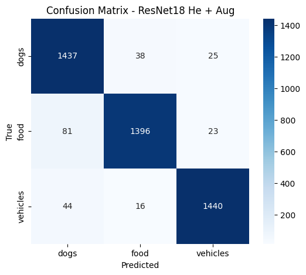

```python
import seaborn as sns
import numpy as np

cm = confusion_matrix(all_labels, all_preds)
plt.figure(figsize=(6, 5))
sns.heatmap(cm, annot=True, fmt="d", cmap="Blues", xticklabels=dataset.classes, yticklabels=dataset.classes)
plt.xlabel("Predicted")
plt.ylabel("True")
plt.title("Confusion Matrix - ResNet18 He + Aug")
plt.show()
```

The model performs very well across all classes, with over 1390 correct predictions in each.

Misclasification between Dog and Food is the most common source of confusion:

- 81 images of food were misclassified as dogs
- 38 images of dogs were misclassified as food

Vehicles are the most accurately identified class:

- Only 25 dogs and 23 food images were misclassified as vehicles, while 1440 were correctly classified.

These misclassifications likely result from visual similarity in texture, shape, or background elements shared between food and animal classes.

Class-wise Precision, Recall, F1

```python
precision, recall, f1, _ = precision_recall_fscore_support(all_labels, all_preds)

for idx, cls in enumerate(dataset.classes):
    print(f"\nClass: {cls}")
    print(f" Precision: {precision[idx]:.4f}")
    print(f" Recall   : {recall[idx]:.4f}")
    print(f" F1 Score : {f1[idx]:.4f}")
```

```
Class: dogs
 Precision: 0.9200
 Recall   : 0.9580
 F1 Score : 0.9386

Class: food
 Precision: 0.9628
 Recall   : 0.9307
 F1 Score : 0.9464

Class: vehicles
 Precision: 0.9677
 Recall   : 0.9600
 F1 Score : 0.9639
```

These scores highlight the model’s strong ability to distinguish between visually similar classes while maintaining high accuracy across all categories.

Display Misclassified Images

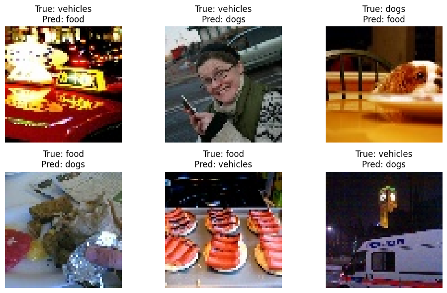

```python
import random

misclassified = []

with torch.no_grad():
    for images, labels in test_loader_fixed:
        images, labels = images.to(device), labels.to(device)
        outputs = model(images)
        _, preds = torch.max(outputs, 1)
        for img, pred, label in zip(images, preds, labels):
            if pred != label:
                misclassified.append((img.cpu(), pred.item(), label.item()))


plt.figure(figsize=(10, 6))
for i in range(6):
    img, pred, label = random.choice(misclassified)
    img = img * std + mean
    plt.subplot(2, 3, i+1)
    plt.imshow(img.permute(1, 2, 0).clip(0, 1))
    plt.title(f"True: {dataset.classes[label]}\nPred: {dataset.classes[pred]}")
    plt.axis("off")

plt.tight_layout()
plt.show()
```

(Img 1): It seems to be a hood of a red-coloured taxi car. Even a human could not identify it at first glance. The model might mistaken it as a table of dinner and therefore predicted it as food.

(Img 2): A human figure obstructed a clear view of the vehicle, leading the model to assume it was a dog based on the shape of the face and the colour of the fur. In the other scenario, the image displayed only the side of a vehicle along with an object that resembled a character, which likely caused the prediction to be a dog.

(Img 3): In this image, a dog was incorrectly identified as food. The dog blended in with its surroundings, and a small part of a plate was visible, which may have contributed to the model's confusion in classifying it as food.

(Img 4): The image mistakenly classifies food as a dog presents dark and brown-coloured food. Only part of the food is visible, and it doesn't resemble a vehicle, which likely led the model to misclassify it as a dog.

(Img 5)The food is recognised as a vehicle, and it is placed on a colourful table. The rounded appearance of the food might have led the model to misinterpret it as the wheels of a vehicle.

(Img 6): The image shows a side view of a vehicle, and there is a figure-like bright object in the middle of the photo; therefore, that figure might have influenced the model to predict it as a dog.

# **Plot & Compare ResNet vs VGG**

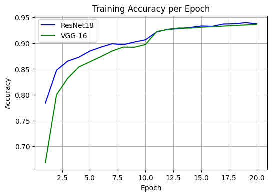

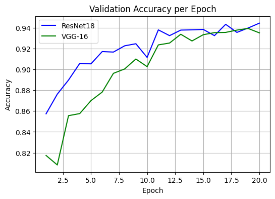

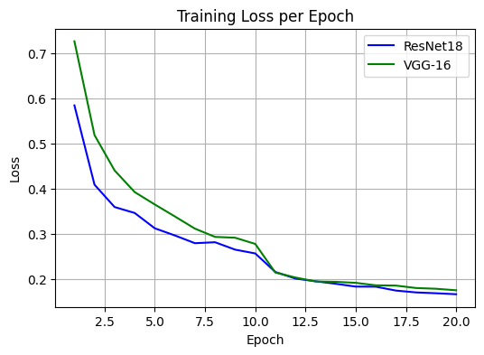

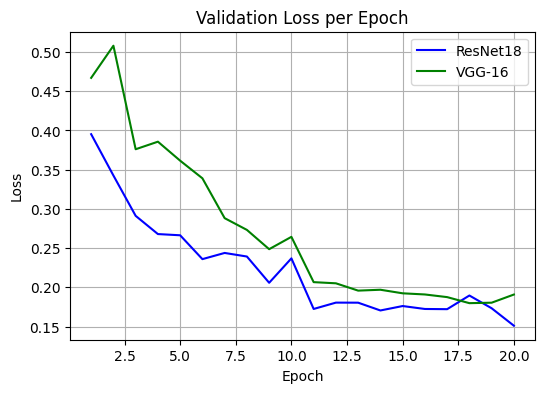

```python
import pickle
import matplotlib.pyplot as plt

# Load saved histories
with open("resnet18_he_aug_history.pkl", "rb") as f:
    resnet = pickle.load(f)

with open("vgg16_xavier_sgd_32_aug_reg_history.pkl", "rb") as f:
    vgg = pickle.load(f)

epochs = range(1, len(resnet["train_acc"]) + 1)

# 1. Training Accuracy
plt.figure(figsize=(6, 4))
plt.plot(epochs, resnet["train_acc"], label="ResNet18", color="blue")
plt.plot(epochs, vgg["train_acc"], label="VGG-16", color="green")
plt.title("Training Accuracy per Epoch")
plt.xlabel("Epoch")
plt.ylabel("Accuracy")
plt.legend()
plt.grid(True)
plt.show()

# 2. Validation Accuracy
plt.figure(figsize=(6, 4))
plt.plot(epochs, resnet["val_acc"], label="ResNet18", color="blue")
plt.plot(epochs, vgg["val_acc"], label="VGG-16", color="green")
plt.title("Validation Accuracy per Epoch")
plt.xlabel("Epoch")
plt.ylabel("Accuracy")
plt.legend()
plt.grid(True)
plt.show()

# 3. Training Loss
plt.figure(figsize=(6, 4))
plt.plot(epochs, resnet["train_loss"], label="ResNet18", color="blue")
plt.plot(epochs, vgg["train_loss"], label="VGG-16", color="green")
plt.title("Training Loss per Epoch")
plt.xlabel("Epoch")
plt.ylabel("Loss")
plt.legend()
plt.grid(True)
plt.show()

# 4. Validation Loss
plt.figure(figsize=(6, 4))
plt.plot(epochs, resnet["val_loss"], label="ResNet18", color="blue")
plt.plot(epochs, vgg["val_loss"], label="VGG-16", color="green")
plt.title("Validation Loss per Epoch")
plt.xlabel("Epoch")
plt.ylabel("Loss")
plt.legend()
plt.grid(True)
plt.show()
```

The training accuracy comparison between ResNet-18 and VGG-16 across 20 epochs highlights notable differences in learning dynamics. In the early stages of training, ResNet-18 consistently demonstrates higher accuracy, suggesting that it converges more quickly than VGG-16. This early advantage becomes especially evident in the first 5–7 epochs, where ResNet leverages its architectural strengths to capture relevant features with fewer updates.

As training progresses, VGG-16 gradually closes the performance gap, eventually approaching the accuracy of ResNet-18 in the later epochs. However, ResNet-18 maintains a slight but consistent lead throughout, ultimately achieving marginally higher training accuracy. This outcome reinforces the efficacy of residual connections, which enable deeper networks to learn more efficiently by preserving gradient flow during backpropagation. In contrast, the deeper layers of VGG-16 may struggle more with vanishing gradients due to its plain architecture.

Overall, the training accuracy trend suggests that ResNet-18 is not only faster to train but also slightly more robust during optimization. For tasks requiring quicker convergence or limited training time, this advantage is significant. These observations, aligned with ResNet’s theoretical design, support the use of residual architectures in deeper CNNs, especially when computational efficiency and stability are priorities.

6. Save the weights of the trained network.

```python
# Load best trained weights
model.load_state_dict(torch.load("resnet18_he_aug_best_model.pt"))
torch.save(model.state_dict(), "a1_part2_resnet_ellawela.pt")
```

## Step 4: Discussion and conclusion

1. Explain the theoretical concepts behind VGG and ResNet.

**VGG-16** is a deep convolutional neural network architecture that emphasizes simplicity and depth. It uses a consistent design of 3×3 convolutional filters stacked in series to build deeper feature hierarchies. By stacking multiple small filters instead of using larger ones (e.g., 5×5 or 7×7), VGG is able to achieve the same receptive field while keeping the number of parameters manageable. The increased depth allows the model to learn more complex representations, but at the cost of increased computational demands and potential training instability as the network gets deeper.

**ResNet-18**, in contrast, was designed to explicitly address the vanishing/exploding gradient problem that arises in very deep neural networks. As layers are added, gradients can shrink or grow exponentially, making training unstable. ResNet introduces residual connections, shortcuts that skip one or more layers and directly add the input of a block to its output. These connections implement an identity mapping, ensuring that even if intermediate layers fail to learn, the network can still pass forward useful signals. This allows the model to effectively train much deeper architectures, leading to stronger performance without degradation.

2. Discuss the impact of regularization and optimization techniques.

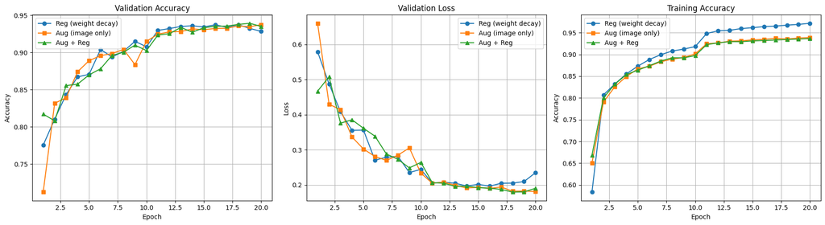

The experimental results show that regularization and augmentation both improved performance, but in different ways. Weight decay alone (blue line) led to the highest training accuracy, suggesting strong memorization of training data. However, this came with a slight gap in validation accuracy and a small increase in validation loss near the end, indicating mild overfitting.

Image augmentation alone (orange line) resulted in lower training accuracy, but similar or slightly better validation accuracy in early epochs. This implies that augmentation made the model more robust by introducing variability, helping it generalize better despite a slower convergence.

The combination of augmentation and weight decay (green line) offered the most balanced performance: stable training accuracy, consistently low validation loss, and competitive validation accuracy by the end of training. This suggests that combining regularization techniques can provide a more generalizable model without sacrificing performance.

3. Analyze the results, including all required graphs and metrics.

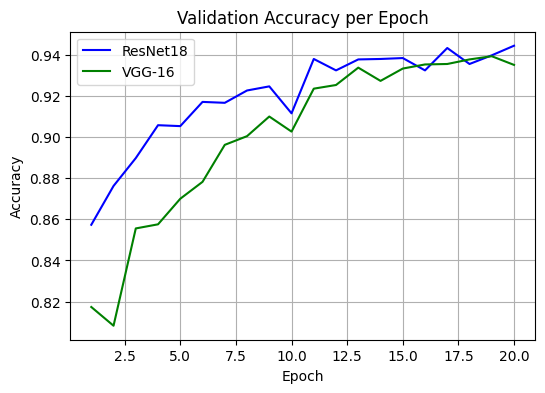

Based on the final evaluation metrics and plots, ResNet-18 outperformed VGG-16 across all key indicators: training accuracy, validation accuracy, test accuracy, and loss values. While both models achieved similar training accuracy (~93.7%), ResNet-18 achieved higher generalization, as indicated by better validation accuracy (94.44% vs 93.51%) and a notably higher test accuracy (94.96% vs 93.38%). Moreover, ResNet-18’s test loss (0.1354) was substantially lower than that of VGG-16 (0.1793), indicating a more confident and stable output distribution.

The accuracy and loss curves confirm these results. ResNet-18 demonstrated a smoother learning trajectory and maintained strong performance across epochs. The training accuracy plot shows that ResNet-18 consistently outpaced VGG-16 early on, and both converged closely by epoch 20. However, ResNet’s validation metrics improved more steadily, showing better generalization under similar training conditions.

For dogs, ResNet had better recall (0.9580 vs 0.9147) and a slightly higher F1 score.

For food, ResNet had both higher precision and F1 (0.9464 vs 0.9272).

For vehicles, ResNet again performed better across all metrics, with an F1 score of 0.9639 compared to 0.9532.

These gains reflect the architectural advantage of ResNet's residual connections, which help deeper models train effectively by mitigating vanishing gradient problems. This allows the network to learn more expressive features, especially beneficial when regularized with augmentation.

ResNet-18, trained with He initialization and image augmentation, clearly outperformed VGG-16 in nearly every quantitative and qualitative measure. Its higher accuracy, lower loss, stronger per-class metrics, and smoother training dynamics demonstrate that it is better suited for this classification task. The architectural innovation of residual learning gives it a notable edge, enabling deeper and more effective feature extraction while maintaining stability and generalization.

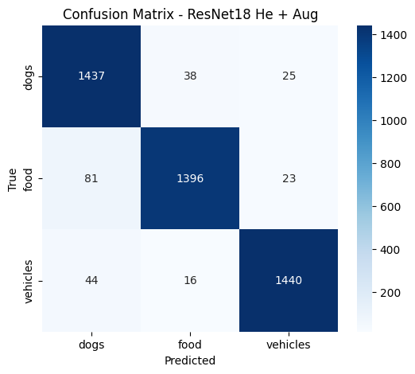

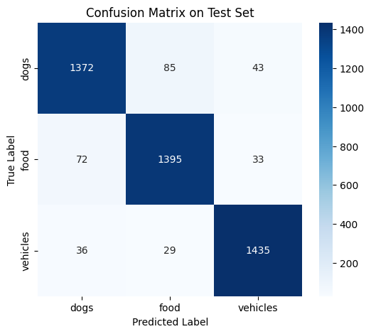

- ResNet-18 shows superior classification performance with fewer misclassifications across all classes. For instance, in the “dogs” class, ResNet-18 misclassifies only 63 samples (vs. 128 for VGG-16).
- Misclassification in ResNet-18 is generally more balanced and consistent, whereas VGG-16 tends to confuse "dogs" and "food" more prominently.

# **Why ResNet Performs Better:**

ResNet-18 benefits from residual connections, allowing gradients to flow more effectively during backpropagation, reducing vanishing gradients and improving optimization. This architecture generalizes better on deeper networks, unlike VGG-16 which can suffer from performance degradation without those skip connections.

4. Summarize your findings and discuss the advantages of residual connections.

We evaluated two prominent CNN architectures : VGG-16 (with data augmentation + weight decay) and ResNet-18 (with data augmentation + He initialization), to determine their suitability for a 3-class image classification task. The table below summarizes the key evaluation metrics across training, validation, and test phases.

| Metric | **VGG-16** | **ResNet-18** |
| --- | --- | --- |
| **Training Accuracy** | 0.9365 | 0.9377 |
| **Training Loss** | 0.1753 | 0.1665 |
| **Validation Accuracy** | 0.9351 | 0.9444 |
| **Validation Loss** | 0.1909 | 0.1511 |
| **Test Accuracy** | 0.9338 | 0.9496 |
| **Test Loss** | 0.1793 | 0.1354 |
| **Best Val Accuracy** | 0.9393 | 0.9444 |
| **Training Time** | 10.16 mins | 9.05 mins |

VGG-16 struggled most with dog vs food, misclassifying 85 dog images as food and 43 as vehicles.

ResNet-18 significantly reduced this confusion: only 38 dogs → food and 25 dogs → vehicles.

Across all classes, ResNet-18 exhibited tighter clustering of predictions around the diagonal, showing higher class consistency

| Class | **Metric** | **VGG-16** | **ResNet-18** |
| --- | --- | --- | --- |
| Dogs | Precision | **0.9270** | 0.9200 |
|  | Recall | 0.9147 | **0.9580** |
|  | F1 Score | 0.9208 | **0.9386** |
| Food | Precision | 0.9245 | **0.9628** |
|  | Recall | 0.9300 | 0.9307 |
|  | F1 Score | 0.9272 | **0.9464** |
| Vehicles | Precision | 0.9497 | **0.9677** |
|  | Recall | 0.9567 | 0.9600 |
|  | F1 Score | 0.9532 | **0.9639** |

ResNet-18 leads in 8 out of 9 class-specific metrics, most notably in recall for dogs (0.9580 vs 0.9147), which suggests better sensitivity to hard-to-detect instances.

# Key Differences and Role of Residual Connections

The fundamental architectural distinction lies in ResNet-18’s residual blocks, which allow gradients to skip across layers via identity shortcuts.

This:

- Enables deeper networks to converge more effectively
- Prevents vanishing gradients during backpropagation
- Encourages learning refinements over base representations, improving generalization

In contrast, VGG-16, despite its depth and regularization, showed:

- Slightly slower convergence
- More overfitting tendencies (larger train-val loss gap)
- Higher confusion on visually ambiguous classes

# **Performance**

Beyond accuracy and generalization, ResNet-18 is significantly more efficient in terms of memory and parameter count. The trained ResNet model weights occupies only ~45MB, while the VGG-16 counterpart exceeds 600MB. This reflects their core architectural differences: VGG-16 uses large fully connected layers and lacks shortcut connections, leading to over 130 million parameters. In contrast, ResNet-18 introduces residual blocks that reduce the need for extremely deep or wide layers, resulting in just ~11 million parameters. This makes ResNet more efficient for deployment, especially on resource constrained devices, while still delivering superior or comparable accuracy.

# Recommendation

Based on the experimental results, ResNet-18 outperformed VGG-16 in accuracy, loss, training time, and class-wise F1 scores.

The residual learning paradigm in ResNet-18 demonstrated clear advantages in stability and precision, especially under augmentation and weight-initialized regimes.

Recommended Model: ResNet-18 with He Initialization + Augmentation

It offers the best balance of performance, efficiency, and robustness for this multi-class image classification task.

5. References.
- Simonyan, K., & Zisserman, A. (2014). Very Deep Convolutional Networks for Large-Scale Image Recognition. arXiv preprint arXiv:1409.1556.
- He, K., Zhang, X., Ren, S., & Sun, J. (2015). Deep Residual Learning for Image Recognition. arXiv preprint arXiv:1512.03385.
- PyTorch Documentation: https://pytorch.org/docs/stable/index.html
- Torchvision Documentation: https://pytorch.org/vision/stable/index.html
- PyTorch Transforms (Image Preprocessing): https://pytorch.org/vision/stable/transforms.html
- ImageFolder Dataset: https://pytorch.org/vision/stable/generated/torchvision.datasets.ImageFolder.html
- Saving/Loading Models (PyTorch): https://pytorch.org/tutorials/beginner/saving_loading_models.html
- PyTorch DataLoader Tutorial: https://pytorch.org/tutorials/beginner/basics/data_tutorial.html
- PyTorch Dropout Layer: https://pytorch.org/docs/stable/generated/torch.nn.Dropout.html
- PyTorch Learning Rate Scheduler (StepLR): https://pytorch.org/docs/stable/generated/torch.optim.lr_scheduler.StepLR.html
- TorchSummary (Model Summary): https://github.com/sksq96/pytorch-summary
- Scikit-learn Metrics Overview: https://scikit-learn.org/stable/modules/classes.html#module-sklearn.metrics
- Precision/Recall/F1 API: https://scikit-learn.org/stable/modules/generated/sklearn.metrics.precision_recall_fscore_support.html
- Confusion Matrix API: https://scikit-learn.org/stable/modules/generated/sklearn.metrics.confusion_matrix.html
- F1 Score Explanation (Wikipedia): https://en.wikipedia.org/wiki/F-score
- Seaborn for Visualization: https://seaborn.pydata.org/
- Matplotlib Plotting Library: https://matplotlib.org/stable/index.html